# Flight Analysis in the U.S.

1. Introduction
2. Import Data & Libraries
3. Understanding Data
4. Data Pre-Processing/Cleaning
5. Exploratory Data Analysis (EDA))
6. Q1. Best time, day and time of year to minimise flight delays?
7. Q2. Are older planes more prone to delays?
8. Q3. Show how the no. of people flying between various locations change with time.
9. Q4. Can cascading failures where an airport's delay causing delay in another be detected?
10. Q5. Construct a model predicting delays.

# Introduction

Every year, nearly 25% of airline flights are delayed or cancelled, costing travellers over $30 billion in lost time and money. Flight delays have long been a cause of dissatisfaction in the airline industry, as well as a source of annoyance for passengers and carriers.

Our goal is to use the massive amount of airline data to visualise and study the flight patterns and predict if a flight will be delayed. For this study, both Python and R will be used to investigate 2 years’ worth of data, since two full business cycles are adequate in reducing bias for one cycle.

This notebook aims to look at these questions regarding flight travel:

1. Best time, day and time of year to minimise flight delays?
2. Are older planes more prone to delays?
3. Show how the no. of people flying between various locations change with time.
4. Can cascading failures where an airport's delay causing delay in another be detected?
5. Construct a model predicting delays.

The dataset can be retrieved from [Airlines - Harvard Dataverse](https://doi.org/10.7910/DVN/HG7NV7)

# Import Data & Libraries

```python
import pandas as pd
import numpy as np
import matplotlib.pyplot as plt
%matplotlib inline
import seaborn as sns
from sklearn.model_selection import train_test_split
import warnings
warnings.filterwarnings("ignore")
```

```python
df_2006 = pd.read_csv(r"D:/et4_e/coursework/2021/2006.csv.bz2")
df_2007 = pd.read_csv(r"D:/et4_e/coursework/2021/2007.csv.bz2")
airport_df = pd.read_csv(r"D:/et4_e/coursework/2021/airports.csv")
carrier_df = pd.read_csv(r"D:/et4_e/coursework/2021/carriers.csv")
planes_df = pd.read_csv(r"D:/et4_e/coursework/2021/plane-data.csv")
merged_df = pd.concat([df_2007,df_2006],ignore_index=True)
```

# Understanding Data

```python
# To view all columns
pd.set_option('display.max_columns', None)
```

```python
merged_df.head()
```

|  | Year | Month | DayofMonth | DayOfWeek | DepTime | CRSDepTime | ArrTime | CRSArrTime | UniqueCarrier | FlightNum | TailNum | ActualElapsedTime | CRSElapsedTime | AirTime | ArrDelay | DepDelay | Origin | Dest | Distance | TaxiIn | TaxiOut | Cancelled | CancellationCode | Diverted | CarrierDelay | WeatherDelay | NASDelay | SecurityDelay | LateAircraftDelay |
| --- | --- | --- | --- | --- | --- | --- | --- | --- | --- | --- | --- | --- | --- | --- | --- | --- | --- | --- | --- | --- | --- | --- | --- | --- | --- | --- | --- | --- | --- |
| 0 | 2007 | 1 | 1 | 1 | 1232.0 | 1225 | 1341.0 | 1340 | WN | 2891 | N351 | 69.0 | 75.0 | 54.0 | 1.0 | 7.0 | SMF | ONT | 389 | 4 | 11 | 0 | NaN | 0 | 0 | 0 | 0 | 0 | 0 |
| 1 | 2007 | 1 | 1 | 1 | 1918.0 | 1905 | 2043.0 | 2035 | WN | 462 | N370 | 85.0 | 90.0 | 74.0 | 8.0 | 13.0 | SMF | PDX | 479 | 5 | 6 | 0 | NaN | 0 | 0 | 0 | 0 | 0 | 0 |
| 2 | 2007 | 1 | 1 | 1 | 2206.0 | 2130 | 2334.0 | 2300 | WN | 1229 | N685 | 88.0 | 90.0 | 73.0 | 34.0 | 36.0 | SMF | PDX | 479 | 6 | 9 | 0 | NaN | 0 | 3 | 0 | 0 | 0 | 31 |
| 3 | 2007 | 1 | 1 | 1 | 1230.0 | 1200 | 1356.0 | 1330 | WN | 1355 | N364 | 86.0 | 90.0 | 75.0 | 26.0 | 30.0 | SMF | PDX | 479 | 3 | 8 | 0 | NaN | 0 | 23 | 0 | 0 | 0 | 3 |
| 4 | 2007 | 1 | 1 | 1 | 831.0 | 830 | 957.0 | 1000 | WN | 2278 | N480 | 86.0 | 90.0 | 74.0 | -3.0 | 1.0 | SMF | PDX | 479 | 3 | 9 | 0 | NaN | 0 | 0 | 0 | 0 | 0 | 0 |

```python
# Find dimension of merged data
print(df_2006.shape,df_2007.shape)
merged_df.shape
```

```
(7141922, 29) (7453215, 29)
```

```
(14595137, 29)
```

There are almost 14.6 million records with 29 variable columns. The columns include the airline and flight details etc. and are mostly time-related (in mins).

```python
merged_df.info()
```

```
<class 'pandas.core.frame.DataFrame'>
RangeIndex: 14595137 entries, 0 to 14595136
Data columns (total 29 columns):
 #   Column             Dtype
---  ------             -----
 0   Year               int64
 1   Month              int64
 2   DayofMonth         int64
 3   DayOfWeek          int64
 4   DepTime            float64
 5   CRSDepTime         int64
 6   ArrTime            float64
 7   CRSArrTime         int64
 8   UniqueCarrier      object
 9   FlightNum          int64
```

[output cut: 21 more lines]

```python
merged_df.describe().T
```

|  | count | mean | std | min | 25% | 50% | 75% | max |
| --- | --- | --- | --- | --- | --- | --- | --- | --- |
| Year | 14595137.0 | 2006.510664 | 0.499886 | 2006.0 | 2006.0 | 2007.0 | 2007.0 | 2007.0 |
| Month | 14595137.0 | 6.538310 | 3.425110 | 1.0 | 4.0 | 7.0 | 10.0 | 12.0 |
| DayofMonth | 14595137.0 | 15.728207 | 8.783863 | 1.0 | 8.0 | 16.0 | 23.0 | 31.0 |
| DayOfWeek | 14595137.0 | 3.941697 | 1.992110 | 1.0 | 2.0 | 4.0 | 6.0 | 7.0 |
| DepTime | 14312455.0 | 1339.795582 | 478.215967 | 1.0 | 930.0 | 1329.0 | 1732.0 | 2930.0 |
| CRSDepTime | 14595137.0 | 1331.404610 | 463.654205 | 0.0 | 930.0 | 1324.0 | 1720.0 | 2359.0 |
| ArrTime | 14279090.0 | 1484.467382 | 504.090036 | 1.0 | 1108.0 | 1515.0 | 1911.0 | 2955.0 |
| CRSArrTime | 14595137.0 | 1495.574683 | 480.164376 | 0.0 | 1115.0 | 1520.0 | 1906.0 | 2400.0 |
| FlightNum | 14595137.0 | 2187.446435 | 1980.504301 | 1.0 | 587.0 | 1501.0 | 3499.0 | 9619.0 |
| ActualElapsedTime | 14279090.0 | 126.193699 | 71.248664 | 5.0 | 75.0 | 108.0 | 156.0 | 1879.0 |
| CRSElapsedTime | 14594139.0 | 127.218035 | 70.336905 | -1240.0 | 77.0 | 109.0 | 157.0 | 1430.0 |
| AirTime | 14279090.0 | 102.834872 | 72.382622 | -1425.0 | 54.0 | 84.0 | 131.0 | 1958.0 |
| ArrDelay | 14279090.0 | 9.451859 | 38.000104 | -592.0 | -9.0 | -1.0 | 13.0 | 2598.0 |
| DepDelay | 14312455.0 | 10.758819 | 34.877805 | -1200.0 | -4.0 | 0.0 | 10.0 | 2601.0 |
| Distance | 14595137.0 | 723.814232 | 568.335124 | 11.0 | 317.0 | 569.0 | 951.0 | 4962.0 |
| TaxiIn | 14595137.0 | 6.872862 | 22.081397 | 0.0 | 4.0 | 5.0 | 8.0 | 1501.0 |
| TaxiOut | 14595137.0 | 16.028638 | 11.565315 | 0.0 | 10.0 | 13.0 | 19.0 | 602.0 |
| Cancelled | 14595137.0 | 0.019368 | 0.137815 | 0.0 | 0.0 | 0.0 | 0.0 | 1.0 |
| Diverted | 14595137.0 | 0.002286 | 0.047758 | 0.0 | 0.0 | 0.0 | 0.0 | 1.0 |
| CarrierDelay | 14595137.0 | 3.635713 | 19.870826 | 0.0 | 0.0 | 0.0 | 0.0 | 2580.0 |
| WeatherDelay | 14595137.0 | 0.725823 | 9.085721 | 0.0 | 0.0 | 0.0 | 0.0 | 1429.0 |
| NASDelay | 14595137.0 | 3.686945 | 15.910850 | 0.0 | 0.0 | 0.0 | 0.0 | 1392.0 |
| SecurityDelay | 14595137.0 | 0.027288 | 1.183342 | 0.0 | 0.0 | 0.0 | 0.0 | 382.0 |
| LateAircraftDelay | 14595137.0 | 4.813299 | 20.598181 | 0.0 | 0.0 | 0.0 | 0.0 | 1366.0 |

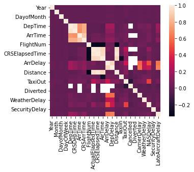

```python
# Correlation Matrix
corrmat = merged_df.corr()
sns.heatmap(corrmat, square=True)
plt.show()
```

Both ArrDelay and DepDelay has a moderately higher correlation with LateAircraftDelay, CarrierDelay and NASDelay.

```python
# Checking the amount of cancelled flights
merged_df.Cancelled.sum()
```

```
282682
```

# Data Pre-Processing/Cleaning

```python
# Check for missing value
merged_df.isna().sum()
```

```
Year                        0
Month                       0
DayofMonth                  0
DayOfWeek                   0
DepTime                282682
CRSDepTime                  0
ArrTime                316047
CRSArrTime                  0
UniqueCarrier               0
FlightNum                   0
TailNum                    22
ActualElapsedTime      316047
CRSElapsedTime            998
AirTime                316047
ArrDelay               316047
DepDelay               282682
Origin                      0
Dest                        0
Distance                    0
TaxiIn                      0
TaxiOut                     0
Cancelled                   0
CancellationCode     14312454
Diverted                    0
CarrierDelay                0
WeatherDelay                0
NASDelay                    0
SecurityDelay               0
LateAircraftDelay           0
dtype: int64
```

Missing data is also handled using linear interpolation to estimate unknown data values between known data values, and duplicates are removed.

```python
# Check for duplicates
len(merged_df[merged_df.duplicated()])
```

```
34
```

```python
# Drop duplicates
merged_df = merged_df.drop_duplicates()
```

```python
# Create Date column
merged_df['Date'] = pd.to_datetime(dict(year=merged_df.Year, month=merged_df.Month, day=merged_df.DayofMonth))
merged_df.sample(3)[['Year','Month','DayofMonth','Date']]
```

|  | Year | Month | DayofMonth | Date |
| --- | --- | --- | --- | --- |
| 9989370 | 2006 | 5 | 15 | 2006-05-15 |
| 10679957 | 2006 | 6 | 6 | 2006-06-06 |
| 13945296 | 2006 | 11 | 9 | 2006-11-09 |

```python
# Create labelled column for easier visualisation
merged_df['Month_label'] = pd.to_datetime(merged_df['Date']).dt.month_name().str[:3]
merged_df['Day_label'] = pd.to_datetime(merged_df['Date']).dt.day_name().str[:3]
```

```python
# Rename 'Cancelled' and 'Diverted' columns from numeric values to categorical values
merged_df['Cancelled'] = merged_df['Cancelled'].replace([1, 0], ["Cancelled", "Not Cancelled"])
merged_df['Diverted'] = merged_df['Diverted'].replace([1, 0], ["Diverted", "Not Diverted"])
```

```python
# Rename CancellationCodes
CancellationCodes = {"A" : "Carrier", "B" : "Weather", "C" : "National Air System (NAS)", "D" : "Security"}
merged_df["CancellationCode"].replace(CancellationCodes, inplace=True)
```

```python
# Change selected data types (numeric to categorical)
merged_df['Year'] = merged_df['Year'].astype(object)
merged_df['Month'] = merged_df['Month'].astype(object)
merged_df['DayofMonth'] = merged_df['DayofMonth'].astype(object)
merged_df['DayOfWeek'] = merged_df['DayOfWeek'].astype(object)
merged_df['FlightNum'] = merged_df['FlightNum'].astype(object)
merged_df['Cancelled'] = merged_df['Cancelled'].astype(object)
merged_df['Diverted'] = merged_df['Diverted'].astype(object)
```

```python
# Imputate Null values with interpolation
merged_df['DepTime'] = merged_df['DepTime'].interpolate(limit_direction='both', axis=0)
merged_df['ArrTime'] = merged_df['ArrTime'].interpolate(limit_direction='both', axis=0)
merged_df['ActualElapsedTime'] = merged_df['ActualElapsedTime'].interpolate(limit_direction ='both', axis=0)
merged_df['CRSElapsedTime'] = merged_df['CRSElapsedTime'].interpolate(limit_direction ='both', axis=0)
merged_df['AirTime'] = merged_df['AirTime'].interpolate(limit_direction ='both', axis=0)
merged_df['ArrDelay'] = merged_df['ArrDelay'].interpolate(limit_direction ='both', axis=0)
merged_df['DepDelay'] = merged_df['DepDelay'].interpolate(limit_direction ='both', axis=0)
```

```python
# Remove the 22 missing TailNum data since it is insignificant compared to the large dataset
merged_df = merged_df[merged_df['TailNum'].notna()]
```

```python
# Checking for missing values
merged_df.isnull().sum()
```

```
Year                        0
Month                       0
DayofMonth                  0
DayOfWeek                   0
DepTime                     0
CRSDepTime                  0
ArrTime                     0
CRSArrTime                  0
UniqueCarrier               0
FlightNum                   0
TailNum                     0
ActualElapsedTime           0
CRSElapsedTime              0
AirTime                     0
ArrDelay                    0
DepDelay                    0
Origin                      0
Dest                        0
Distance                    0
TaxiIn                      0
TaxiOut                     0
Cancelled                   0
CancellationCode     14312420
Diverted                    0
CarrierDelay                0
WeatherDelay                0
NASDelay                    0
SecurityDelay               0
LateAircraftDelay           0
Date                        0
Month_label                 0
Day_label                   0
dtype: int64
```

CancellationCode is filled with 14.3 million missing values since non-cancelled flights do not have a Cancellation Code.

### Creating Delay Status

We assume that a delayed flight is equivalent to arriving late for more than 15 minutes at its destination. (ArrDelay > 15 mins)

Since flights can be delayed on its Departure but still arrive on time, hence we do not classify those as a delayed flight.  
Hence we create a DelayStatus column into the main dataframe (merged_df), where 0 = No Delay, 1 = Delay.

```python
# Creating new column showing ArrDelay > 15mins
# 0 = No Delay, 1= Delay

merged_df['DelayStatus'] = np.where(merged_df['ArrDelay']>15, '1','0')
merged_df
```

|  | Year | Month | DayofMonth | DayOfWeek | DepTime | CRSDepTime | ArrTime | CRSArrTime | UniqueCarrier | FlightNum | TailNum | ActualElapsedTime | CRSElapsedTime | AirTime | ArrDelay | DepDelay | Origin | Dest | Distance | TaxiIn | TaxiOut | Cancelled | CancellationCode | Diverted | CarrierDelay | WeatherDelay | NASDelay | SecurityDelay | LateAircraftDelay | … |
| --- | --- | --- | --- | --- | --- | --- | --- | --- | --- | --- | --- | --- | --- | --- | --- | --- | --- | --- | --- | --- | --- | --- | --- | --- | --- | --- | --- | --- | --- | --- |
| 0 | 2007 | 1 | 1 | 1 | 1232.0 | 1225 | 1341.0 | 1340 | WN | 2891 | N351 | 69.0 | 75.0 | 54.0 | 1.0 | 7.0 | SMF | ONT | 389 | 4 | 11 | Not Cancelled | NaN | Not Diverted | 0 | 0 | 0 | 0 | 0 | … |
| 1 | 2007 | 1 | 1 | 1 | 1918.0 | 1905 | 2043.0 | 2035 | WN | 462 | N370 | 85.0 | 90.0 | 74.0 | 8.0 | 13.0 | SMF | PDX | 479 | 5 | 6 | Not Cancelled | NaN | Not Diverted | 0 | 0 | 0 | 0 | 0 | … |
| 2 | 2007 | 1 | 1 | 1 | 2206.0 | 2130 | 2334.0 | 2300 | WN | 1229 | N685 | 88.0 | 90.0 | 73.0 | 34.0 | 36.0 | SMF | PDX | 479 | 6 | 9 | Not Cancelled | NaN | Not Diverted | 3 | 0 | 0 | 0 | 31 | … |
| 3 | 2007 | 1 | 1 | 1 | 1230.0 | 1200 | 1356.0 | 1330 | WN | 1355 | N364 | 86.0 | 90.0 | 75.0 | 26.0 | 30.0 | SMF | PDX | 479 | 3 | 8 | Not Cancelled | NaN | Not Diverted | 23 | 0 | 0 | 0 | 3 | … |
| 4 | 2007 | 1 | 1 | 1 | 831.0 | 830 | 957.0 | 1000 | WN | 2278 | N480 | 86.0 | 90.0 | 74.0 | -3.0 | 1.0 | SMF | PDX | 479 | 3 | 9 | Not Cancelled | NaN | Not Diverted | 0 | 0 | 0 | 0 | 0 | … |
| ... | ... | ... | ... | ... | ... | ... | ... | ... | ... | ... | ... | ... | ... | ... | ... | ... | ... | ... | ... | ... | ... | ... | ... | ... | ... | ... | ... | ... | ... | … |
| 14595132 | 2006 | 12 | 29 | 5 | 1246.0 | 1249 | 1452.0 | 1459 | DL | 1675 | N905DE | 126.0 | 130.0 | 108.0 | -7.0 | -3.0 | ATL | EWR | 745 | 6 | 12 | Not Cancelled | NaN | Not Diverted | 0 | 0 | 0 | 0 | 0 | … |
| 14595133 | 2006 | 12 | 29 | 5 | 1225.0 | 1155 | 2033.0 | 1931 | DL | 1676 | N651DL | 308.0 | 276.0 | 261.0 | 62.0 | 30.0 | SEA | ATL | 2182 | 12 | 35 | Not Cancelled | NaN | Not Diverted | 30 | 0 | 32 | 0 | 0 | … |
| 14595134 | 2006 | 12 | 29 | 5 | 2118.0 | 2115 | 2254.0 | 2241 | DL | 1676 | N143DA | 96.0 | 86.0 | 60.0 | 13.0 | 3.0 | ATL | MCO | 403 | 9 | 27 | Not Cancelled | NaN | Not Diverted | 0 | 0 | 0 | 0 | 0 | … |
| 14595135 | 2006 | 12 | 29 | 5 | 2122.0 | 2127 | 2209.0 | 2223 | DL | 1677 | N904DA | 107.0 | 116.0 | 81.0 | -14.0 | -5.0 | SLC | SJC | 585 | 5 | 21 | Not Cancelled | NaN | Not Diverted | 0 | 0 | 0 | 0 | 0 | … |
| 14595136 | 2006 | 12 | 29 | 5 | 2042.0 | 2045 | 2213.0 | 2235 | DL | 1678 | N914DN | 211.0 | 230.0 | 191.0 | -22.0 | -3.0 | CVG | SLC | 1449 | 5 | 15 | Not Cancelled | NaN | Not Diverted | 0 | 0 | 0 | 0 | 0 | … |

14595081 rows × 33 columns

```python
merged_df.DelayStatus.value_counts()
```

```
0    11169298
1     3425783
Name: DelayStatus, dtype: int64
```

```python
merged_df.DelayStatus.value_counts(normalize=True)
```

```
0    0.765278
1    0.234722
Name: DelayStatus, dtype: float64
```

```python
# Delayed Flights in Year 2006
merged_df.loc[merged_df['Year'] == 2006].DelayStatus.value_counts(normalize=True)
```

```
0    0.775126
1    0.224874
Name: DelayStatus, dtype: float64
```

```python
# Delayed Flights in Year 2007
merged_df.loc[merged_df['Year'] == 2007].DelayStatus.value_counts(normalize=True)
```

```
0    0.755842
1    0.244158
Name: DelayStatus, dtype: float64
```

Additionally, there was also a 2% increase in delayed flights in 2007 compared to 2006.

### Creating sample of entire data

Due to the large dataset requiring more time to execute, we will randomly select 10% of the data for quick analysis.

We then filter the data into Cancelled and Non-cancelled flights.

```python
merged_df_sample = merged_df.sample(frac=0.10, replace=False, random_state = 42)

flight_cancelled = merged_df_sample.query("Cancelled == 'Cancelled'")
flight_notcancelled = merged_df_sample.query("Cancelled == 'Not Cancelled'")
```

```python
merged_df_sample.shape
```

```
(1459508, 33)
```

### Checking for outliers

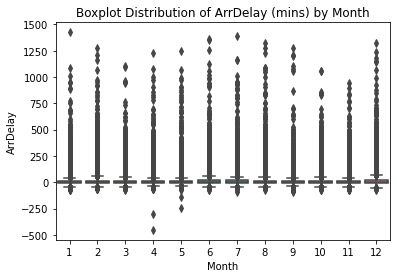

```python
sns.boxplot(x=merged_df_sample["Month"], y=merged_df_sample["ArrDelay"] )
plt.title('Boxplot Distribution of ArrDelay (mins) by Month')
```

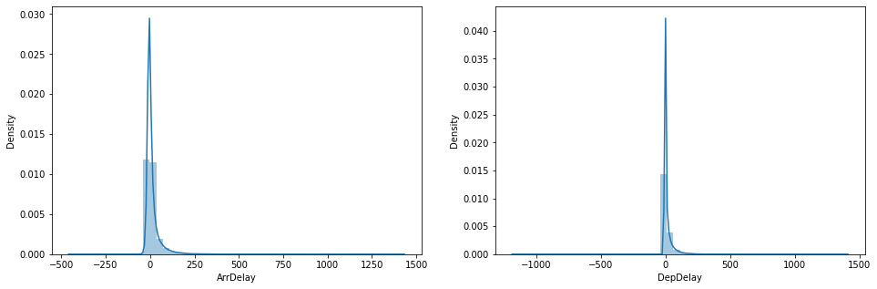

```python
plt.figure(figsize=(16,5))
plt.subplot(1,2,1)
sns.distplot(merged_df_sample['ArrDelay'])
plt.subplot(1,2,2)
sns.distplot(merged_df_sample['DepDelay'])

plt.show()
```

Outliers are not removed since the full data would better represent the delays and our further analysis.

### Checking for missing data between Origin & Dest

```python
len(airport_df.iata.unique())
```

```
3376
```

```python
print('There are ', len(flight_notcancelled.Origin.unique()), ' Unique Origin Airport Codes.')
print('There are ', len(flight_notcancelled.Dest.unique()), ' Unique Destination Airport Codes.')
```

```
There are  305  Unique Origin Airport Codes.
There are  306  Unique Destination Airport Codes.
```

We can see that there is an unequal number of Origin and Destination Airport Codes.  
Hence we will investigate the different airports not listed and whether they have a significant count.

```python
df_origin = flight_notcancelled.Origin.unique()
df_dest = flight_notcancelled.Dest.unique()
```

```python
difference_1 = [item for item in df_origin if item not in df_dest]
print(difference_1 , 'is in Origin but not in Dest.')
```

```
['PIR', 'GLH'] is in Origin but not in Dest.
```

```python
difference_2 = [item for item in df_dest if item not in df_origin]
print(difference_2 , 'are in Dest but not in Origin.')
```

```
['PVU', 'PUB', 'OGD'] are in Dest but not in Origin.
```

```python
# Finding total flights from above difference_2
flight_notcancelled.query('(Dest == "PVU") | (Dest == "PUB") | (Dest == "OGD")').Dest.count()
```

```
4
```

```python
flight_notcancelled.query('(Origin == "GLH")|(Origin == "PIR")').Origin.count()
```

```
2
```

The 5 airports that are not similar in the Origin and Dest data only has 6 flights in total out of the sample of 1.46 million flights, hence it is not significant enough for us to make changes.

# Exploratory Data Analysis (EDA)

We will be looking at the different variables to get a better understanding of the data.

1. Total Flight Distribution
2. Cancellation
3. Delayed Flights

## Total Flight Distribution

#### Total Flight Distribution of Full Data by Month

```python
print("Percentage count of each month:")
print(merged_df.Month.value_counts(normalize=True))

print("Percentage count of each day:")
print(merged_df.DayOfWeek.value_counts(normalize=True))
```

```
Percentage count of each month:
8     0.087838
7     0.087001
3     0.085262
10    0.085077
5     0.084585
6     0.084110
12    0.083514
1     0.082414
4     0.082219
11    0.081626
9     0.081200
2     0.075152
Name: Month, dtype: float64
Percentage count of each day:
1    0.148030
5    0.147877
4    0.147357
3    0.146063
2    0.144493
7    0.140599
6    0.125581
Name: DayOfWeek, dtype: float64
```

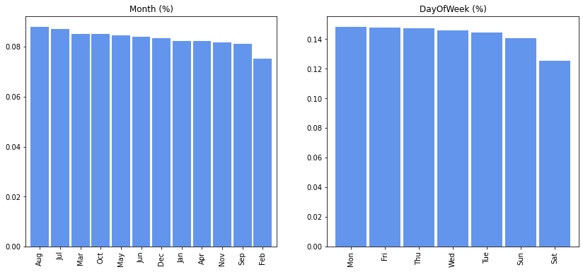

```python
# Full data
fig, (ax1, ax2) = plt.subplots(ncols=2, figsize=(14, 6))

# bar plot for cancellation
ax1.set_title('Month (%)')
merged_df.Month_label.value_counts(normalize=True).plot.bar(color='cornflowerblue', width=0.9, ax=ax1)

# bar plot for diverted
ax2.set_title('DayOfWeek (%)')
p1= merged_df.Day_label.value_counts(normalize=True).plot.bar(color='cornflowerblue', width=0.9, ax=ax2)

plt.show()
```

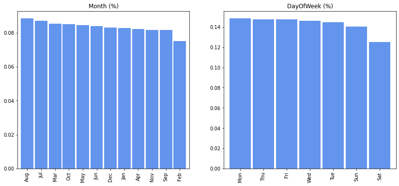

```python
# Sample
fig, (ax1, ax2) = plt.subplots(ncols=2, figsize=(14, 6))

# bar plot for cancellation
ax1.set_title('Month (%)')
merged_df_sample.Month_label.value_counts(normalize=True).plot.bar(color = 'cornflowerblue', width=0.9, ax=ax1)

# bar plot for diverted
ax2.set_title('DayOfWeek (%)')
p1= merged_df_sample.Day_label.value_counts(normalize=True).plot.bar(color = 'cornflowerblue', width=0.9, ax=ax2)

plt.show()
```

The data is almost evenly distributed between Month and DayOfWeek, with February and Saturday having the least number of total flights.

#### Total Number of Flights per Airline

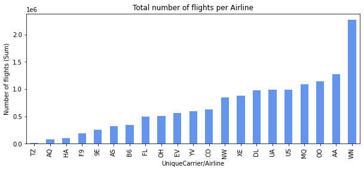

```python
plt.figure(figsize=(10, 4))
merged_df['UniqueCarrier'].value_counts().sort_values().plot(kind = 'bar',color='cornflowerblue')
plt.title('Total number of flights per Airline')
plt.xlabel('UniqueCarrier/Airline')
plt.ylabel('Number of flights (Sum)')

plt.show()
```

```python
carrier_df.query("Code == 'WN' or Code == 'AA' or Code == 'OO'or Code == 'MQ'or Code == 'UA'")
```

|  | Code | Description |
| --- | --- | --- |
| 100 | AA | American Airlines Inc. |
| 848 | MQ | American Eagle Airlines Inc. |
| 949 | OO | Skywest Airlines Inc. |
| 1297 | UA | United Air Lines Inc. |
| 1388 | WN | Southwest Airlines Co. |

The top 5 airlines with the most flights are WN, AA, OO, MQ, UA.

1. Southwest Airlines
2. American Airlines
3. Skywest Airlines
4. American Eagle Airlines
5. United Airlines

#### Distribution of Distance

```
The Mean Distance for Non-Cancelled flights is 726.5590713246221 miles.
```

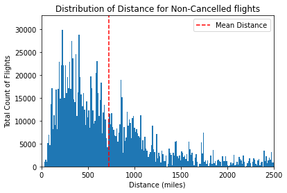

```python
plt.hist(x=flight_notcancelled['Distance'], bins='auto')
plt.xlabel('Distance (miles)')
plt.ylabel('Frequency')

meandist = flight_notcancelled.Distance.mean()
plt.axvline(x = meandist, color = 'red', linestyle = '--', label = 'Mean Distance')
print('The Mean Distance for Non-Cancelled flights is', meandist, 'miles.')

plt.xlim([0, 2500])
plt.ylim([0, 33000])
plt.xlabel('Distance (miles)')
plt.ylabel('Total Count of Flights')
plt.legend()
plt.title('Distribution of Distance for Non-Cancelled flights')

plt.show()
```

```
The Mean Distance for Cancelled flights is 567.0817275275915 miles.
```

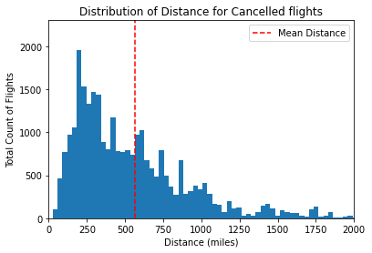

```python
plt.hist(x=flight_cancelled['Distance'], bins='auto')
plt.xlabel('Distance (miles)')
plt.ylabel('Frequency')

meandist = flight_cancelled.Distance.mean()
plt.axvline(x = meandist, color = 'red', linestyle = '--', label = 'Mean Distance')
print('The Mean Distance for Cancelled flights is', meandist, 'miles.')

plt.xlim([0, 2000])
plt.ylim([0, 2300])
plt.xlabel('Distance (miles)')
plt.ylabel('Total Count of Flights')
plt.legend()
plt.title('Distribution of Distance for Cancelled flights')

plt.show()
```

## Cancellation

Cancelled flights are analysed as well to have a better understanding of the data.

The main areas of focus:

- Cancellation Reasons (CancellationCodes)
- Carriers with the most cancelled flights
- Month & Day with the most cancelled flights

#### Cancellation Reasons

CancellationCodes were previously changed to its category name to better visualise the data. We then compare the results to the sampled data of cancellation flights to see if it is suitable representative of the data.

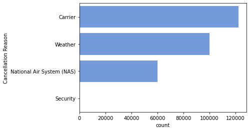

```python
sns.countplot(data=merged_df, y = 'CancellationCode', color = 'cornflowerblue',
            order = merged_df['CancellationCode'].value_counts().index)
plt.ylabel('Cancellation Reason')
```

```python
merged_df['CancellationCode'].value_counts(normalize=True)
```

```
Carrier                      0.433134
Weather                      0.353183
National Air System (NAS)    0.212990
Security                     0.000693
Name: CancellationCode, dtype: float64
```

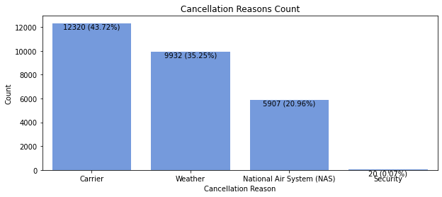

```python
plt.figure(figsize = (10,4))

order = flight_cancelled['CancellationCode'].value_counts().index
sns.countplot(data = flight_cancelled, x = 'CancellationCode', order = order , color = 'cornflowerblue')

# Include count and %
for bar in range(flight_cancelled['CancellationCode'].value_counts().shape[0]):
    count = flight_cancelled['CancellationCode'].value_counts()[bar]
    pct = (round(flight_cancelled['CancellationCode'].value_counts(normalize=True), 5)*100).round(2)[bar]
    plt.text(x=bar, y=count, s=f"{count} ({pct}%)", va='top', ha='center')

plt.xlabel('Cancellation Reason')
plt.ylabel('Count')
plt.title('Cancellation Reasons Count')

plt.show()
```

The sample data can accurately represent the main data.  
We can also conclude that Cancellations are mostly due to Carrier, Weather and NAS with 43.72%, 35.25% and 20.96% respectively.

#### Cancelled Flights Distribution

```python
# Cancelled Flights in Year 2006
merged_df.loc[merged_df['Year'] == 2006].Cancelled.value_counts(normalize=True)
```

```
Not Cancelled    0.982927
Cancelled        0.017073
Name: Cancelled, dtype: float64
```

```python
# Cancelled Flights in Year 2007
merged_df.loc[merged_df['Year'] == 2007].Cancelled.value_counts(normalize=True)
```

```
Not Cancelled    0.978435
Cancelled        0.021565
Name: Cancelled, dtype: float64
```

There were more cancelled flights in 2007 than in 2006.

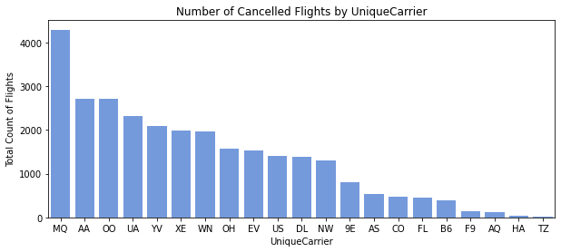

```python
plt.figure(figsize = (10,4))
order =  flight_cancelled.UniqueCarrier.value_counts().index
sns.countplot(data = flight_cancelled , x = 'UniqueCarrier', order = order , color = 'cornflowerblue')

plt.xlabel('UniqueCarrier')
plt.ylabel('Total Count of Flights')
plt.title('Number of Cancelled Flights by UniqueCarrier')

plt.show()
```

```python
carrier_df.query("Code == 'MQ' or Code == 'AA' or Code == 'OO'")
```

|  | Code | Description |
| --- | --- | --- |
| 100 | AA | American Airlines Inc. |
| 848 | MQ | American Eagle Airlines Inc. |
| 949 | OO | Skywest Airlines Inc. |

The top 3 most cancelled flights throughout these 2 years are:

1. American Eagle Airlines
2. American Airlines
3. Skywest Airlines

#### Month & Day with the most cancelled flights

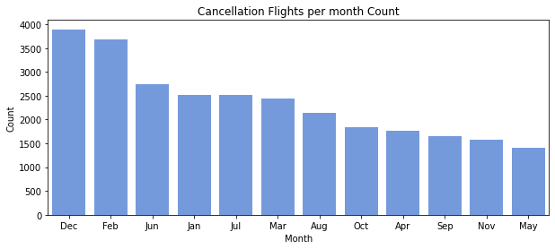

```python
plt.figure(figsize = (10,4))

order = flight_cancelled['Month_label'].value_counts().index
sns.countplot(data = flight_cancelled , x = 'Month_label', order = order , color = 'cornflowerblue')

plt.xlabel('Month')
plt.ylabel('Count')
plt.title('Cancellation Flights per month Count')

plt.show()
```

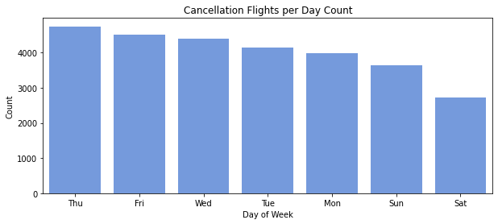

```python
plt.figure(figsize = (10,4))

# Plot
order = flight_cancelled['Day_label'].value_counts().index
sns.countplot(data = flight_cancelled , x = 'Day_label', order = order , color = 'cornflowerblue')

plt.xlabel('Day of Week')
plt.ylabel('Count')
plt.title('Cancellation Flights per Day Count')

plt.show()
```

The flights are mostly likely to be cancelled in December and February, on a Thursday and Friday.

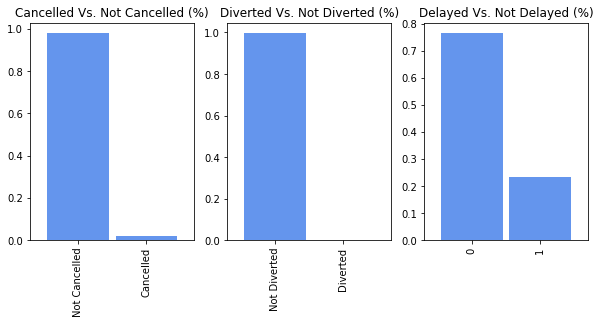

```python
fig, (ax1, ax2, ax3) = plt.subplots(ncols=3, figsize=(10, 4))

# bar plot for cancellation
ax1.set_title('Cancelled Vs. Not Cancelled (%)')
merged_df_sample.Cancelled.value_counts(normalize=True).plot.bar(color = 'cornflowerblue', width=0.9, ax=ax1)

# bar plot for diverted
ax2.set_title('Diverted Vs. Not Diverted (%)')
p1= merged_df_sample.Diverted.value_counts(normalize=True).plot.bar(color = 'cornflowerblue', width=0.9, ax=ax2)

# bar plot for delayed
ax3.set_title('Delayed Vs. Not Delayed (%)')
p1= merged_df_sample.DelayStatus.value_counts(normalize=True).plot.bar(color = 'cornflowerblue', width=0.9, ax=ax3)

plt.show()
```

## Delayed Flights

Delayed flights are then analysed in these areas:

- Relationship between ArrDelay & Depdelay
- Relationship of Type of Delay & Average ArrDelay
- Total Sum of Delay (per Airline))

#### Relationship between ArrDelay & Depdelay

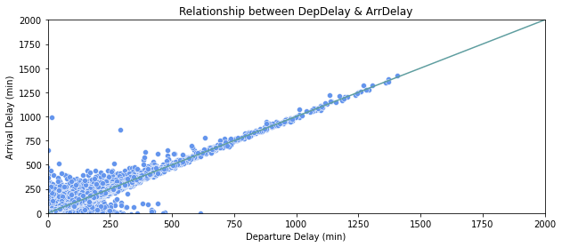

```python
plt.figure(figsize=(10,4))

# plot
sns.scatterplot(x='DepDelay', y='ArrDelay', data=merged_df_sample, color = 'cornflowerblue')

# line to know max of all scores
line = max(max(merged_df['DepDelay']) , max(merged_df['ArrDelay']))
plt.plot([0,line], [0,line], color = 'cadetblue')

plt.xlabel('Departure Delay (min)')
plt.ylabel('Arrival Delay (min)')
plt.title('Relationship between DepDelay & ArrDelay')

plt.xlim([0, 2000])
plt.ylim([0, 2000])

plt.show()
```

ArrDelay and DepDelay have a strong positive linear relationship, implying that a Departure Delay will almost certainly result in an Arrival Delay.

```
The Mean Distance is 723.4800117573867 miles.
```

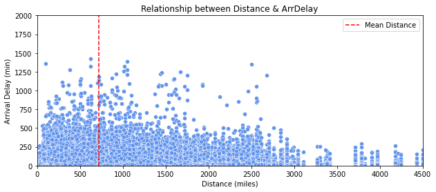

```python
plt.figure(figsize=(10,4))

# plot
sns.scatterplot(x='Distance', y='ArrDelay', data=merged_df_sample, color = 'cornflowerblue')

# Mean line
meandist = merged_df_sample.Distance.mean()
plt.axvline(x = meandist, color = 'red', linestyle = '--', label = 'Mean Distance')
print('The Mean Distance is', meandist, 'miles.')

plt.legend()
plt.xlabel('Distance (miles)')
plt.ylabel('Arrival Delay (min)')
plt.title('Relationship between Distance & ArrDelay')

plt.xlim([0, 4500])
plt.ylim([0, 2000])

plt.show()
```

No exact relationship but we can infer from the mean that shorter distance flights might have higher chance of delay.

#### Relationship of Type of Delay & Average ArrDelay

```python
# Create new dataframe considering only delayed flights
delay15 = flight_notcancelled[flight_notcancelled.ArrDelay > 15]
```

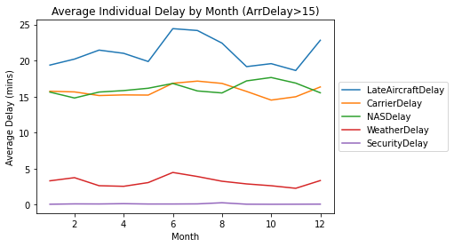

```python
diff_delay = delay15.filter(['Month','CarrierDelay','WeatherDelay','NASDelay','SecurityDelay','LateAircraftDelay'], axis=1)
diff_delay = diff_delay.groupby('Month')['LateAircraftDelay','CarrierDelay','NASDelay','WeatherDelay','SecurityDelay'].mean().plot()

plt.legend(loc='center left', bbox_to_anchor=(1, 0.5))
plt.xlabel('Month')
plt.ylabel('Average Delay (mins)')
plt.title('Average Individual Delay by Month (ArrDelay>15)')

plt.show()
```

On average, LateAircraftDelay has the highest average ArrDelay, followed by CarrierDelay and NASDelay.  
We can refer to the correlation heatmap above that these factors are also the more significant variables causing delays.

#### Total Sum of Delay (per Airline)

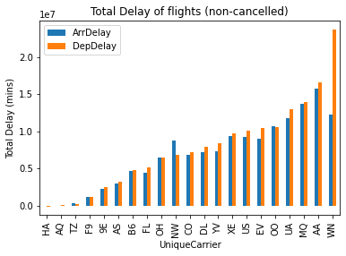

```python
merged_df[['UniqueCarrier','ArrDelay','DepDelay']].groupby(['UniqueCarrier']).sum().sort_values(by='DepDelay').plot(kind='bar')

plt.legend()
plt.ylabel('Total Delay (mins)')
plt.title("Total Delay of flights (non-cancelled)")

plt.show()
```

```python
carrier_df.query("Code == 'WN' or Code == 'AA' or Code == 'MQ'or Code == 'UA'or Code == 'OO'")
```

|  | Code | Description |
| --- | --- | --- |
| 100 | AA | American Airlines Inc. |
| 848 | MQ | American Eagle Airlines Inc. |
| 949 | OO | Skywest Airlines Inc. |
| 1297 | UA | United Air Lines Inc. |
| 1388 | WN | Southwest Airlines Co. |

The top 5 Carriers with the highest Total Delay (mins) of Delayed flights are

1. Southwest Airlines
2. American Airlines
3. American Eagle Airlines
4. United Air Lines
5. Skywest Airlines

However, it is unsubstantiable to assume that Southwest Airline flights are usually delayed since it has the highest total delayed minutes. Hence we will further investigate the proportion and justify if this pattern was caused by Southwest Airlines having more flights than the others.

# Q1. Best time, day and time of year to minimise flight delays?

We will breakdown this question into four parts, where we will find the airline carrier and time period least likely to have delayed flights:

- Best Time of the Day
- Best Day of the Week
- Best Month of the Year
- Best Day of the Month
- Delayed Flights (%) per Airline-per-Airline)

## Best Time of the Day

### Distribution of Average Delay by Time Period

```python
# Create copy of dataframe
df_q1 = flight_notcancelled.copy()
```

24 hours in a day will split into 6 different periods with at least 3 to 5-hour intervals since different timings like 5am and 11am are better not generalised together into a single timeframe. The period is split as such:

- Midnight (12am - 5am)
- Early Morning (5am - 9am)
- Late Morning (9am - 12pm)
- Afternoon (12pm - 5pm)
- Evening (5pm - 9pm)
- Night (9pm - 12am)

Time Interval column ‘ArrPeriod’ was created based on ‘ArrTime’.

```python
# Categorising ArrTime and DepTime by 6 periods: Midnight, Early Morning, Late Morning, Afternoon, Evening, Night
def time_interval(cols):
    if cols >= 500 and cols < 900:
        return "Early Morning"
    elif cols >= 900 and cols < 1200:
        return "Late Morning"
    elif cols >= 1200 and cols < 1700:
        return "Afternoon"
    elif cols >= 1700 and cols < 2100:
        return "Evening"
    elif cols >= 2100 and cols < 2400:
        return "Night"
    else:
        return "Midnight"

# Getting Time Period for ArrTime and DepTime
df_q1['ArrPeriod'] = df_q1["ArrTime"].apply(time_interval)
df_q1['DepPeriod'] = df_q1["DepTime"].apply(time_interval)

# Setting order for the Period
df_q1['ArrPeriod'] = pd.Categorical(df_q1['ArrPeriod'],
                                   categories=['Midnight','Early Morning','Late Morning', 'Afternoon', 'Evening', 'Night'],
                                   ordered=True)
df_q1['DepPeriod'] = pd.Categorical(df_q1['DepPeriod'],
                                   categories=['Midnight','Early Morning','Late Morning', 'Afternoon', 'Evening', 'Night'],
                                   ordered=True)
```

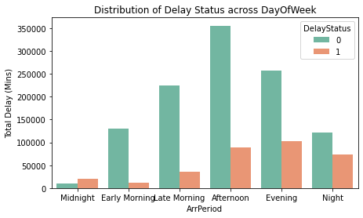

```python
# Comparing Delay Status Distribution
plt.figure(figsize=(7,4))

sns.countplot(x="ArrPeriod", hue="DelayStatus", data=df_q1, palette="Set2")

plt.ylabel('Total Delay (Mins)')
plt.title("Distribution of Delay Status across DayOfWeek")

plt.show()
```

Early Morning followed by Midnight has the lowest count for number of flights delayed. However, we will proceed on to check if having the lowest number of count will equate to the shortest average delayed time.

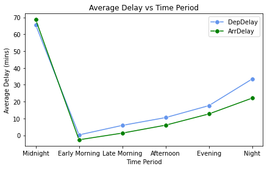

```python
plt.figure(figsize=(7,4))

# Plot for DepDelay
x= df_q1.groupby('DepPeriod').mean().index
y= df_q1.groupby('DepPeriod').DepDelay.mean().values
sns.lineplot(x, y, marker='.', markersize=15, color='cornflowerblue', label='DepDelay')

# Plot for ArrDelay
x1= df_q1.groupby('ArrPeriod').mean().index
y2= df_q1.groupby('ArrPeriod').ArrDelay.mean().values
sns.lineplot(x1, y2, marker='.', markersize=15, color='green', label='ArrDelay')

plt.legend()
plt.xlabel('Time Period')
plt.ylabel('Average Delay (mins)')
plt.title("Average Delay vs Time Period")

plt.show()
```

```python
df_q1.groupby('ArrPeriod')['ArrDelay','DepDelay'].mean()
```

| ArrPeriod | ArrDelay | DepDelay |
| --- | --- | --- |
| Midnight | 68.691210 | 67.668800 |
| Early Morning | -2.629913 | -0.329221 |
| Late Morning | 1.326621 | 2.817979 |
| Afternoon | 6.039461 | 7.684434 |
| Evening | 12.699964 | 13.518453 |
| Night | 22.100972 | 22.646892 |

The best time period to minimise flight delays would be in the Early Morning from 5am to 9am.

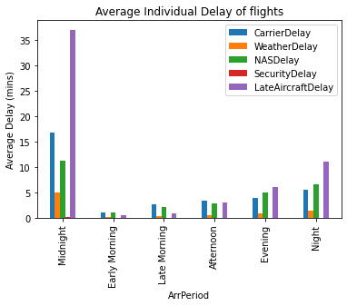

```python
# Bar Chart
df_q1[['ArrPeriod','CarrierDelay','WeatherDelay','NASDelay','SecurityDelay','LateAircraftDelay']].groupby(['ArrPeriod']).mean().sort_values(by='ArrPeriod').plot(kind='bar')

plt.legend()
plt.ylabel('Average Delay (mins)')
plt.title("Average Individual Delay of flights")

plt.show()
```

Midnight Flights are more likely to have longer delays due to LateAircraftDelay (which was caused by cascading failure).  
Early Morning are also less likely to have any of the delay types.

## Best Day of the Week

### Distribution of Day Delay

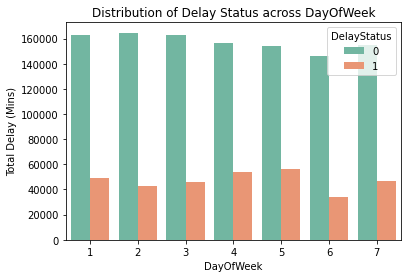

```python
# Comparing Delay Status Distribution

sns.countplot(x="DayOfWeek", hue="DelayStatus", data=flight_notcancelled, palette="Set2")

plt.ylabel('Total Delay (Mins)')
plt.title("Distribution of Delay Status across DayOfWeek")

plt.show()
```

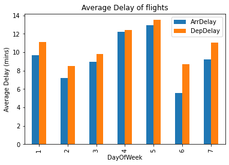

```python
# Bar Chart
flight_notcancelled[['DayOfWeek','ArrDelay','DepDelay']].groupby(['DayOfWeek']).mean().sort_values(by='DayOfWeek').plot(kind='bar')

plt.legend()
plt.ylabel('Average Delay (mins)')
plt.title("Average Delay of flights")

plt.show()
```

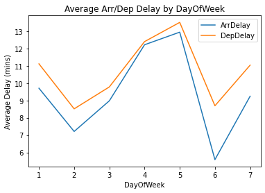

```python
# Line Plot
flight_notcancelled.groupby('DayOfWeek')['ArrDelay','DepDelay'].mean().plot()

plt.legend()
plt.xlabel('DayOfWeek')
plt.ylabel('Average Delay (mins)')
plt.title('Average Arr/Dep Delay by DayOfWeek')

plt.show()
```

```python
flight_notcancelled.groupby('DayOfWeek')['ArrDelay','DepDelay'].mean()
```

| DayOfWeek | ArrDelay | DepDelay |
| --- | --- | --- |
| 1 | 9.706076 | 11.115190 |
| 2 | 7.210507 | 8.516248 |
| 3 | 8.980213 | 9.782257 |
| 4 | 12.216688 | 12.398298 |
| 5 | 12.944968 | 13.509117 |
| 6 | 5.583741 | 8.692829 |
| 7 | 9.244071 | 11.038142 |

Best Day of the Week to minimize delays is to travel on Saturday, followed by Tuesday, with average ArrDelay timing of less than 6 minutes and 8 minutes, respectively.

Saturdays and Tuesdays are also likely to create a 9-minute delay on average for DepDelay. The longest average delays of 12-13 minutes are expected in the middle of the week, from Thursday to Friday.

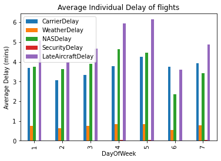

```python
# Bar Chart
flight_notcancelled[['DayOfWeek','CarrierDelay','WeatherDelay','NASDelay','SecurityDelay','LateAircraftDelay']].groupby(['DayOfWeek']).mean().sort_values(by='DayOfWeek').plot(kind='bar')

plt.legend()
plt.ylabel('Average Delay (mins)')
plt.title("Average Individual Delay of flights")

plt.show()
```

Thursday to Friday have a higher average of 6 minutes caused by LateAircraftDelay, as compared to the other days.

## Best Month of the Year

### Distribution of Monthly Delay

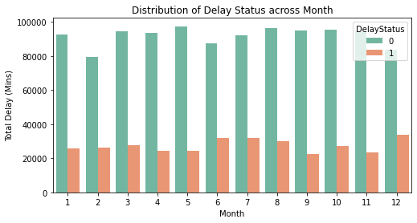

```python
# Comparing Delay Status Distribution
plt.figure(figsize=(8,4))

sns.countplot(x="Month", hue="DelayStatus", data=flight_notcancelled, palette="Set2")

plt.ylabel('Total Delay (Mins)')
plt.title("Distribution of Delay Status across Month")

plt.show()
```

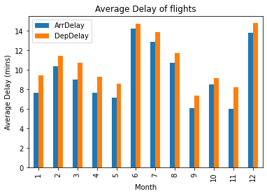

```python
# Bar Chart
plt.figure(figsize=(8,4))

flight_notcancelled[['Month','ArrDelay','DepDelay']].groupby(['Month']).mean().sort_values(by='Month').plot(kind='bar')

plt.legend()
plt.ylabel('Average Delay (mins)')
plt.title("Average Delay of flights")

plt.show()
```

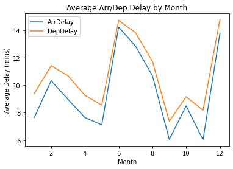

```python
# Line Plot
flight_notcancelled.groupby('Month')['ArrDelay','DepDelay'].mean().plot()

plt.xlabel('Month')
plt.ylabel('Average Delay (mins)')
plt.title('Average Arr/Dep Delay by Month')

plt.show()
```

```python
flight_notcancelled.groupby('Month')['ArrDelay','DepDelay'].mean()
```

| Month | ArrDelay | DepDelay |
| --- | --- | --- |
| 1 | 7.651337 | 9.398433 |
| 2 | 10.335359 | 11.424177 |
| 3 | 8.978117 | 10.694113 |
| 4 | 7.652325 | 9.271485 |
| 5 | 7.121950 | 8.552550 |
| 6 | 14.235764 | 14.722072 |
| 7 | 12.849599 | 13.828892 |
| 8 | 10.701020 | 11.742373 |
| 9 | 6.057809 | 7.386887 |
| 10 | 8.501795 | 9.173222 |
| 11 | 6.033901 | 8.181639 |
| 12 | 13.793222 | 14.782222 |

Based on ArrDelay, the best time of year to minimise travel delay is November, then September, with both averaging approximately 6 minutes of delay, as opposed to June and December, with more than twice the number of minutes delayed.

Based on DepDelay, September will have a roughly 1-minute less average delay than November.

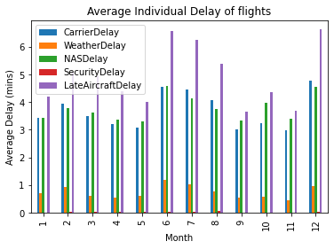

```python
# Bar Chart
flight_notcancelled[['Month','CarrierDelay','WeatherDelay','NASDelay','SecurityDelay','LateAircraftDelay']].groupby(['Month']).mean().sort_values(by='Month').plot(kind='bar')

plt.legend()
plt.ylabel('Average Delay (mins)')
plt.title("Average Individual Delay of flights")

plt.show()
```

Due to the U.S. summer and winter vacation (School Holidays USA, 2022), June and December are projected to be popular months to travel, resulting in increased delays likely caused by LateAircraftDelay.

## Best Day of the Month

### Distribution of DayofMonth Delay

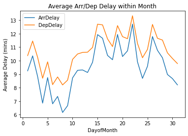

```python
# Line Plot
flight_notcancelled.groupby('DayofMonth')['ArrDelay','DepDelay'].mean().plot()

plt.xlabel('DayofMonth')
plt.ylabel('Average Delay (mins)')
plt.title('Average Arr/Dep Delay within Month')

plt.show()
```

```python
flight_notcancelled.groupby('DayofMonth')['ArrDelay','DepDelay'].mean()
```

| DayofMonth | ArrDelay | DepDelay |
| --- | --- | --- |
| 1 | 9.247080 | 10.374597 |
| 2 | 10.355887 | 11.454968 |
| 3 | 8.818566 | 10.250027 |
| 4 | 6.851954 | 8.697963 |
| 5 | 8.745867 | 9.913006 |
| 6 | 6.803094 | 8.224274 |
| 7 | 7.349336 | 8.793673 |
| 8 | 6.158959 | 8.201658 |
| 9 | 6.664747 | 8.557264 |
| 10 | 8.725496 | 10.097192 |
| 11 | 9.283930 | 10.495677 |
| 12 | 9.310679 | 10.611710 |
| 13 | 9.124182 | 10.629409 |
| 14 | 9.881783 | 10.981216 |
| 15 | 11.931632 | 12.704664 |
| 16 | 11.661524 | 12.653342 |
| 17 | 10.389115 | 11.615786 |
| 18 | 10.069138 | 11.045238 |
| 19 | 11.940864 | 12.599455 |
| 20 | 10.307294 | 11.782669 |
| 21 | 10.730140 | 11.629272 |
| 22 | 12.712159 | 13.327803 |
| 23 | 9.910426 | 11.278571 |
| 24 | 8.688454 | 10.218898 |
| 25 | 9.585357 | 10.836983 |
| 26 | 11.787908 | 12.686850 |
| 27 | 10.766162 | 11.659527 |
| 28 | 10.213926 | 11.527774 |
| 29 | 8.975394 | 10.579391 |
| 30 | 8.671562 | 10.163374 |
| 31 | 8.205463 | 9.786340 |

Also, travelling in the first half of the month, around the 8th – 9th, results in an average ArrDelay of around 6 minutes, DepDelay of less than 9 minutes, and the second half of the month with double the delay amount.

## Delayed Flights (%) per Airline

In addition, we evaluate the airline with the highest percentage of delayed flights to complement the optimal period for minimizing delays.

```python
# Create subset with selected columns
df_FD = flight_notcancelled[['UniqueCarrier', 'DelayStatus']]
```

```python
# Converting to integer type
df_FD['DelayStatus'] = df_FD['DelayStatus'].astype(int)
df_FD.DelayStatus.value_counts()
```

```
0    1102017
1     329312
Name: DelayStatus, dtype: int64
```

```python
# Group the Carriers, add DelayStatus values
try1 = df_FD.groupby(['UniqueCarrier']).sum().reset_index()

# Create dataframe to add all flights
try2 = flight_notcancelled.UniqueCarrier.value_counts().rename_axis('UniqueCarrier').reset_index(name='TotalFlights')

# Create new dataframe with merged data
d_tgt = pd.merge(try1, try2, on='UniqueCarrier')

d_tgt.head()
```

|  | UniqueCarrier | DelayStatus | TotalFlights |
| --- | --- | --- | --- |
| 0 | 9E | 5047 | 25013 |
| 1 | AA | 31593 | 124663 |
| 2 | AQ | 540 | 7949 |
| 3 | AS | 7633 | 31332 |
| 4 | B6 | 8956 | 34198 |

```python
# Adding column to see the percentage of delayed flights
d_tgt['PercentageDelayed'] = round((d_tgt['DelayStatus']*100)/d_tgt['TotalFlights'], 2)
d_tgt.rename({'DelayStatus': 'DelayedFlights'}, axis=1, inplace=True)
```

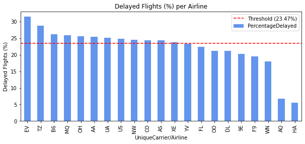

```python
# Set threshold of value of delayed flights as 23.47%
plt.figure(figsize=(10, 4))
d_tgt.groupby('UniqueCarrier').PercentageDelayed.sum().sort_values(ascending=False).plot.bar(color ='cornflowerblue')
plt.hlines(y=23.47, xmin=-2, xmax=21, colors='r', linestyles='--', label='Threshold (23.47%)')

plt.title('Delayed Flights (%) per Airline')
plt.xlabel('UniqueCarrier/Airline')
plt.ylabel('Delayed Flights (%)')
plt.legend()

plt.show()
```

According to our EDA, the total number of delayed flights was 23.47%, thus a threshold line was drawn at that point. Any airlines that exceed that line will have a higher chance of experiencing flight delays.

By comparing the number of flights per airline, we see that Southwest Airlines (WN) and SkyWest Airlines (OO) are in the Top 5 for Total Flights, yet their delayed flights are well below the threshold.

WN is the third least delayed airline, despite having the Highest Number of Flights and the Highest Total Delay (minutes), with about 5% below the threshold value, hence a reliable airline.

OO was also in the Top 5 for both Highest Number of Flights and Highest Total Delay (mins), but its delay percentage is 21.11% which is also below the threshold value.

As a result, airlines falling below the threshold delay value are more reliable and have a lower chance of experiencing flight delays.

Hence overall, the top 2 recommended time period to avoid flight delay is:

- Early Morning (5am-9am) & Late Morning (9am-12pm) (≈0 minutes)
- Saturday & Tuesday (≈6 minutes)
- September & November (≈6 minutes)
- Around 8th – 9th (Specifically on 8th) (≈6 minutes)

All the above periods are delayed by an average of 0 to 6 minutes. Passengers may reduce their flight delays even further by booking flights with airlines that are below the delay threshold (%).

# Q2. Are older planes more prone to delays?

The issue date of planes will be extracted from the planes_df data since we can judge the age of the aircraft and make our analysis based on that.

- Distribution of Arr/Dep Delay by Issue Date
- Distribution of Arr/Dep Delay by Issue Year
- Comparison of Old and Normal Planes

To determine the age of the aircrafts, the engine's issue date is obtained by mapping the plane-data.csv consisting of the plane's ‘issue_date’, into a duplicated data frame of the 'flight_notcancelled' data as a new column.

```python
# Create a new dataframe
df_q2 = flight_notcancelled.copy()
```

```python
# Extract issue_date from plane_df
df_q2['issue_date'] = df_q2['TailNum'].map(planes_df.set_index('tailnum')['issue_date'])
df_q2
```

|  | Year | Month | DayofMonth | DayOfWeek | DepTime | CRSDepTime | ArrTime | CRSArrTime | UniqueCarrier | FlightNum | TailNum | ActualElapsedTime | CRSElapsedTime | AirTime | ArrDelay | DepDelay | Origin | Dest | Distance | TaxiIn | TaxiOut | Cancelled | CancellationCode | Diverted | CarrierDelay | WeatherDelay | NASDelay | SecurityDelay | LateAircraftDelay | … |
| --- | --- | --- | --- | --- | --- | --- | --- | --- | --- | --- | --- | --- | --- | --- | --- | --- | --- | --- | --- | --- | --- | --- | --- | --- | --- | --- | --- | --- | --- | --- |
| 11427221 | 2006 | 7 | 13 | 4 | 2132.0 | 2130 | 18.0 | 24 | AA | 314 | N072AA | 166.0 | 174.0 | 134.0 | -6.0 | 2.0 | MIA | JFK | 1090 | 11 | 21 | Not Cancelled | NaN | Not Diverted | 0 | 0 | 0 | 0 | 0 | … |
| 14306699 | 2006 | 12 | 9 | 6 | 2117.0 | 2120 | 2226.0 | 2225 | EV | 4520 | N758EV | 129.0 | 125.0 | 97.0 | 1.0 | -3.0 | SLC | SFO | 599 | 5 | 27 | Not Cancelled | NaN | Not Diverted | 0 | 0 | 0 | 0 | 0 | … |
| 13821464 | 2006 | 11 | 19 | 7 | 1247.0 | 1250 | 1415.0 | 1430 | NW | 1137 | N309US | 88.0 | 100.0 | 68.0 | -15.0 | -3.0 | BWI | DTW | 408 | 4 | 16 | Not Cancelled | NaN | Not Diverted | 0 | 0 | 0 | 0 | 0 | … |
| 1856981 | 2007 | 4 | 11 | 3 | 1720.0 | 1720 | 1813.0 | 1820 | WN | 39 | N503SW | 53.0 | 60.0 | 44.0 | -7.0 | 0.0 | HOU | HRL | 276 | 2 | 7 | Not Cancelled | NaN | Not Diverted | 0 | 0 | 0 | 0 | 0 | … |
| 14014779 | 2006 | 12 | 11 | 1 | 1832.0 | 1825 | 1937.0 | 1935 | WN | 2310 | N353 | 65.0 | 70.0 | 52.0 | 2.0 | 7.0 | BWI | PVD | 328 | 3 | 10 | Not Cancelled | NaN | Not Diverted | 0 | 0 | 0 | 0 | 0 | … |
| ... | ... | ... | ... | ... | ... | ... | ... | ... | ... | ... | ... | ... | ... | ... | ... | ... | ... | ... | ... | ... | ... | ... | ... | ... | ... | ... | ... | ... | ... | … |
| 481913 | 2007 | 1 | 24 | 3 | 955.0 | 1000 | 1208.0 | 1150 | 9E | 4759 | 88869E | 133.0 | 110.0 | 101.0 | 18.0 | -5.0 | RDU | IND | 489 | 9 | 23 | Not Cancelled | NaN | Not Diverted | 0 | 0 | 18 | 0 | 0 | … |
| 1630112 | 2007 | 3 | 6 | 2 | 1523.0 | 1530 | 1741.0 | 1735 | MQ | 4847 | N729AE | 138.0 | 125.0 | 96.0 | 6.0 | -7.0 | LGA | DTW | 501 | 13 | 29 | Not Cancelled | NaN | Not Diverted | 0 | 0 | 0 | 0 | 0 | … |
| 515861 | 2007 | 1 | 15 | 1 | 1548.0 | 1500 | 2037.0 | 1955 | AA | 1346 | N3CGAA | 169.0 | 175.0 | 136.0 | 42.0 | 48.0 | SNA | DFW | 1205 | 20 | 13 | Not Cancelled | NaN | Not Diverted | 0 | 0 | 4 | 0 | 38 | … |
| 5117427 | 2007 | 9 | 12 | 3 | 1414.0 | 1415 | 1727.0 | 1727 | XE | 7810 | N14173 | 133.0 | 132.0 | 109.0 | 0.0 | -1.0 | LAX | DEN | 862 | 5 | 19 | Not Cancelled | NaN | Not Diverted | 0 | 0 | 0 | 0 | 0 | … |
| 9527990 | 2006 | 4 | 13 | 4 | 1059.0 | 1106 | 1149.0 | 1200 | MQ | 3312 | N376AE | 50.0 | 54.0 | 28.0 | -11.0 | -7.0 | SPS | DFW | 113 | 12 | 10 | Not Cancelled | NaN | Not Diverted | 0 | 0 | 0 | 0 | 0 | … |

1431329 rows × 34 columns

```python
# Check for missing value
df_q2['issue_date'].isna().sum()
```

```
235185
```

```python
# Extract non-missing issue_date dataset
df_q2 = df_q2[df_q2['issue_date'].notna()]
df_q2.drop(df_q2.index[df_q2['issue_date'] == 'None'], inplace = True)
```

```python
# Convert to datetime format
df_q2['issue_date'] = pd.to_datetime(df_q2['issue_date'], format='%m/%d/%Y')
```

## Distribution of Arr/Dep Delay by Issue Date

#### Total Sum of Delay by Issue Date

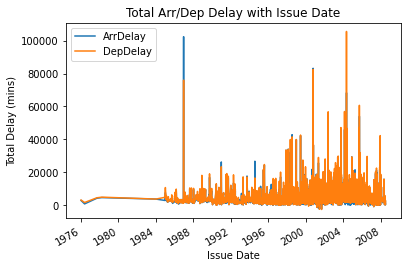

```python
df_q2.groupby('issue_date')['ArrDelay','DepDelay'].sum().plot()

plt.xlabel('Issue Date')
plt.ylabel('Total Delay (mins)')
plt.title('Total Arr/Dep Delay with Issue Date')

plt.show()
```

From the graph, we can see three peak points around year 1986, 2000 and 2004. However, we checked with the value counts and discovered that these dates are in fact those with the highest issue_date counts. Hence, we proceed to check with the mean value.

```python
df_q2['issue_date'].value_counts()
```

```
2004-05-13    9716
1986-12-22    9467
2000-10-20    6618
2002-05-30    6193
2005-09-27    5803
              ...
1991-10-25       2
1997-02-26       1
2007-10-16       1
2007-09-13       1
1997-04-22       1
Name: issue_date, Length: 2367, dtype: int64
```

#### Average Delay with Issue Date

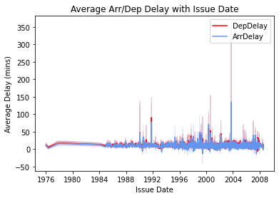

```python
# Plot DepDelay and ArrDelay
sns.lineplot(data=df_q2, x= 'issue_date', y='DepDelay',color = 'red', label= "DepDelay")
sns.lineplot(data=df_q2, x= 'issue_date', y='ArrDelay',color = 'cornflowerblue', label= "ArrDelay")

plt.xlabel('Issue Date')
plt.ylabel('Average Delay (mins)')
plt.title('Average Arr/Dep Delay with Issue Date')
plt.legend()

plt.show()
```

Based on Issue Date, there seem to be more delay occurrences for planes issued after 1998. Also, the low total minutes delayed between 1976 and 1984 might be attributed to planes older than 24 years being removed owing to maintenance faults, or the airline scheduling them with ample time to avoid delays.

## Distribution of Arr/Dep Delay by Issue Year

A new column of issue year and plane age is then extracted from the issue date.

```python
# Extract year value from issue date
df_q2['issue_year'] = df_q2['issue_date'].dt.year
```

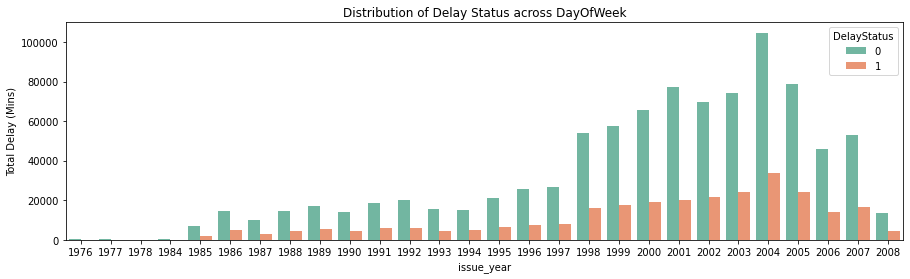

```python
# Comparing Delay Status Distribution
plt.figure(figsize=(15,4))

sns.countplot(x="issue_year", hue="DelayStatus", data=df_q2, palette="Set2")

plt.ylabel('Total Delay (Mins)')
plt.title("Distribution of Delay Status across DayOfWeek")

plt.show()
```

```python
# To find the plane age
df_q2 = df_q2[df_q2.issue_year != 2008]
df_q2['plane_age'] = max(df_q2['issue_year']) - df_q2['issue_year']
```

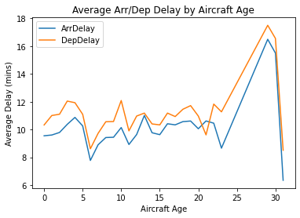

```python
# Line Plot
df_q2.groupby('plane_age')['ArrDelay','DepDelay'].mean().plot()

plt.xlabel('Aircraft Age')
plt.ylabel('Average Delay (mins)')
plt.title('Average Arr/Dep Delay by Aircraft Age')

plt.show()
```

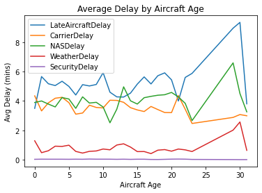

```python
# Plot Delay Types according to its aircraft age
df_q2a = df_q2.filter(['plane_age','CarrierDelay','WeatherDelay','NASDelay','SecurityDelay','LateAircraftDelay'], axis=1)
df_q2a.groupby('plane_age')['LateAircraftDelay','CarrierDelay','NASDelay','WeatherDelay','SecurityDelay'].mean().plot()

plt.legend()
plt.xlabel('Aircraft Age')
plt.ylabel('Avg Delay (mins)')
plt.title('Average Delay by Aircraft Age')

plt.show()
```

Older planes are also more likely to have more delays due to individual average delay factors, such as LateAircraftDelay, which has an average delay of roughly 10 minutes. Those below 20 years of plane age have less than 6 minutes of average delays.

Further investigations will then be made with Issue Date rather than its Year, as delays became increasingly prevalent after year 2000.

## Comparison of Old and Normal Planes

The average age of U.S planes is 11 years, with about 25% of planes above 15 years old (Mayerowitz, 2011).

Hence, we will deem an aircraft to be old when in operation for 15+ years, where data will split into two, with planes issued before 1993 termed old, and those issued 1993 onwards termed normal.

```python
old_planes = df_q2.query("issue_date < '1993-01-01'")
normal_planes = df_q2.query("issue_date > '1992-12-31'")
```

```python
# Create new dataframe considering only delayed flights
old_delay15 = old_planes[old_planes.ArrDelay > 15]
normal_delay15 = normal_planes[normal_planes.ArrDelay > 15]
```

### Distribution of Individual Delays

#### Average Delay by Issue Date per Delay Type

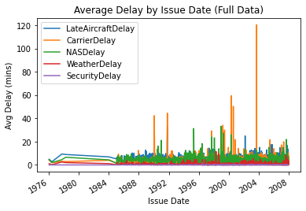

```python
# Plot Delay Types according to its issue date
diff_delay = df_q2.filter(['issue_date','CarrierDelay','WeatherDelay','NASDelay','SecurityDelay','LateAircraftDelay'], axis=1)
diff_delay.groupby('issue_date')['LateAircraftDelay','CarrierDelay','NASDelay','WeatherDelay','SecurityDelay'].mean().plot()

plt.legend()
plt.xlabel('Issue Date')
plt.ylabel('Avg Delay (mins)')
plt.title('Average Delay by Issue Date (Full Data)')

plt.show()
```

The full data shows Carrier Delay being prominent with planes issued 1990-1992 and 2000-2004.

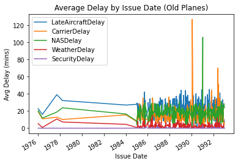

```python
# Plot Delay Types according to its issue date
diff_delay1 = old_delay15.filter(['issue_date','CarrierDelay','WeatherDelay','NASDelay','SecurityDelay','LateAircraftDelay'], axis=1)
diff_delay1.groupby('issue_date')['LateAircraftDelay','CarrierDelay','NASDelay','WeatherDelay','SecurityDelay'].mean().plot()

plt.legend()
plt.xlabel('Issue Date')
plt.ylabel('Avg Delay (mins)')
plt.title('Average Delay by Issue Date (Old Planes)')

plt.show()
```

Old Planes issued around 1990 are more likely to have delays due CarrierDelay, which includes maintainence etc.

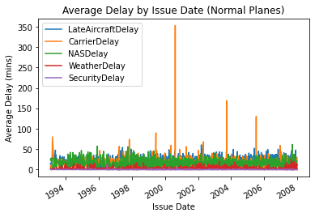

```python
diff_delay2 = normal_delay15.filter(['issue_date','CarrierDelay','WeatherDelay','NASDelay','SecurityDelay','LateAircraftDelay'], axis=1)
diff_delay2.groupby('issue_date')['LateAircraftDelay','CarrierDelay','NASDelay','WeatherDelay','SecurityDelay'].mean().plot()

plt.xlabel('Issue Date')
plt.ylabel('Average Delay (mins)')
plt.title('Average Delay by Issue Date (Normal Planes)')

plt.legend(loc='upper left')
plt.show()
```

Normal Planes are more likely to have CarrierDelays.

### Distance Distribution of Old & Normal Planes

#### Average Delay by Distance

Distance is then used to check the delays that Old and Normal Planes will have with respect to the number of miles that they have travelled.

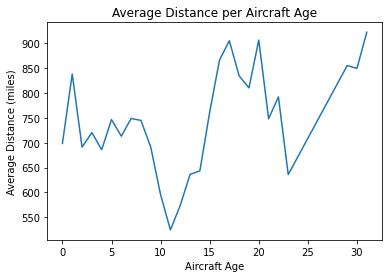

```python
# Line Plot
df_q2.groupby('plane_age')['Distance'].mean().plot()

plt.xlabel('Aircraft Age')
plt.ylabel('Average Distance (miles)')
plt.title('Average Distance per Aircraft Age')

plt.show()
```

As observed, Old planes issued before 1993 had a greater average distance travelled, ranging from 650 to 900 miles. As a result, we can assume that older planes are typically employed for long-haul trips.

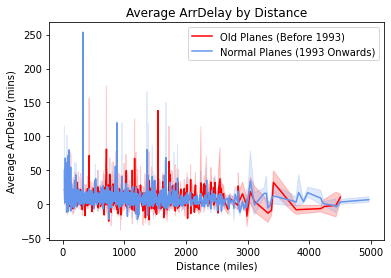

```python
# Plot Old and Normal Planes
sns.lineplot(data=old_planes, x= 'Distance', y='ArrDelay',color = 'red', label= "Old Planes (Before 1993)")
sns.lineplot(data=normal_planes, x= 'Distance', y='ArrDelay',color = 'cornflowerblue', label= "Normal Planes (1993 Onwards)")


plt.xlabel('Distance (miles)')
plt.ylabel('Average ArrDelay (mins)')
plt.title('Average ArrDelay by Distance')

plt.legend()
plt.show()
```

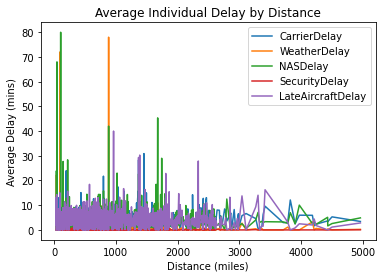

```python
# Line Plot
df_q2.groupby('Distance')['CarrierDelay','WeatherDelay','NASDelay','SecurityDelay','LateAircraftDelay'].mean().plot()

plt.xlabel('Distance (miles)')
plt.ylabel('Average Delay (mins)')
plt.title('Average Individual Delay by Distance')

plt.show()
```

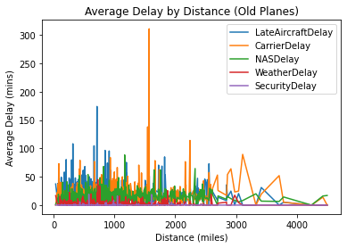

```python
diff_delay3 = old_delay15.filter(['Distance','CarrierDelay','WeatherDelay','NASDelay','SecurityDelay','LateAircraftDelay'], axis=1)
diff_delay3.groupby('Distance')['LateAircraftDelay','CarrierDelay','NASDelay','WeatherDelay','SecurityDelay'].mean().plot()

plt.xlabel('Distance (miles)')
plt.ylabel('Average Delay (mins)')
plt.title('Average Delay by Distance (Old Planes)')

plt.show()
```

When comparing Distance, older planes have more occurrences of having a higher average carrier delay of above 50 minutes for flights around 1500 miles and above 2000 miles.

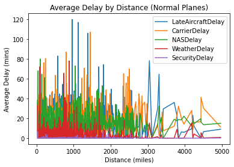

```python
diff_delay4 = normal_delay15.filter(['Distance','CarrierDelay','WeatherDelay','NASDelay','SecurityDelay','LateAircraftDelay'], axis=1)
diff_delay4.groupby('Distance')['LateAircraftDelay','CarrierDelay','NASDelay','WeatherDelay','SecurityDelay'].mean().plot()

plt.xlabel('Distance (miles)')
plt.ylabel('Average Delay (mins)')
plt.title('Average Delay by Distance (Normal Planes)')

plt.show()
```

Hence, it is evident that older planes would suffer more delays by having a larger value of Carrier Delay minutes while flying routes longer than 1500 miles.

```python
df_q2.corr()['plane_age']
```

```
DepTime             -0.000099
CRSDepTime          -0.001067
ArrTime              0.012662
CRSArrTime           0.012775
ActualElapsedTime    0.027313
CRSElapsedTime       0.024720
AirTime              0.025847
ArrDelay             0.002407
DepDelay            -0.002675
Distance             0.022989
TaxiIn              -0.003102
TaxiOut              0.010804
CarrierDelay        -0.007479
WeatherDelay        -0.007438
NASDelay             0.004987
SecurityDelay       -0.000538
LateAircraftDelay    0.004915
issue_year          -1.000000
plane_age            1.000000
Name: plane_age, dtype: float64
```

Lastly, the plane’s age, which ranged from 0 to 31, was correlated against other variables to identify possible related factors. There is a positive linear relationship with most of the variables, but they are all small values that are not explanatory enough to investigate.

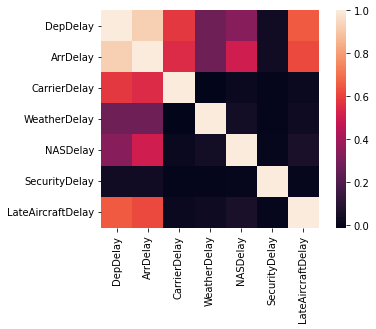

```python
# Create subset of relevant variables then find correlation
subset = df_q2[['DepDelay','ArrDelay','CarrierDelay','WeatherDelay','NASDelay','SecurityDelay','LateAircraftDelay']]
corrmat = subset.corr()
sns.heatmap(corrmat, square=True)
plt.show()
```

Overall, the grouping by Issue Year was clear in showing that older planes do suffer from more delay, but only by up to 8 minutes on average, where LateAircraftDelay, followed by Carrier/NASDelay are the primary causes.

When utilized for long-haul flights, older planes are also more likely to have delays due to carrier delays that might have resulted from aircraft maintenance or inspection.

The difference in delay however is quite negligible and it might be due to airlines “padding” and scheduling extra time for flights to prevent flights from being classified as delayed (Kramer, 2019).

# Q3. Show how the no. of people flying between various locations change with time.

We will find the most popular routes to gauge the number of people flying between these different locations.

- Distribution by Flight Routes
- Distribution by State

```python
# Create new dataframe
df_q3 = flight_notcancelled.copy()
```

### Distribution by Flight Routes

To begin, the Origin and Destination are combined into a new ‘FlightRoute’ column (e.g., OGG to HNL).

```python
# Create new column as its flight route
df_q3["FlightRoute"] = df_q3["Origin"] + " to " + df_q3["Dest"]
```

```python
# Most popular routes
df_q3["FlightRoute"].value_counts()
```

```
OGG to HNL    2975
HNL to OGG    2858
SAN to LAX    2755
LAX to LAS    2749
LAX to SAN    2731
              ...
ORD to RFD       1
MHT to BOS       1
GSO to ROA       1
TYS to AUS       1
BDL to BOS       1
Name: FlightRoute, Length: 5196, dtype: int64
```

Out of the 5196 distinct routes, the Top 5 routes with the highest count are identified to examine if the number of flights has changed over the course of the year.

```python
# Extract the top 5 flight routes
most_flights = df_q3.query("FlightRoute == 'HNL to OGG'|FlightRoute == 'OGG to HNL'|FlightRoute == 'LAX to LAS' |FlightRoute == 'SAN to LAX'|FlightRoute == 'LAX to SAN' ")
most_flights
```

|  | Year | Month | DayofMonth | DayOfWeek | DepTime | CRSDepTime | ArrTime | CRSArrTime | UniqueCarrier | FlightNum | TailNum | ActualElapsedTime | CRSElapsedTime | AirTime | ArrDelay | DepDelay | Origin | Dest | Distance | TaxiIn | TaxiOut | Cancelled | CancellationCode | Diverted | CarrierDelay | WeatherDelay | NASDelay | SecurityDelay | LateAircraftDelay | … |
| --- | --- | --- | --- | --- | --- | --- | --- | --- | --- | --- | --- | --- | --- | --- | --- | --- | --- | --- | --- | --- | --- | --- | --- | --- | --- | --- | --- | --- | --- | --- |
| 2363983 | 2007 | 4 | 7 | 6 | 1853.0 | 1905 | 1923.0 | 1939 | AQ | 67 | N828AL | 30.0 | 34.0 | 22.0 | -16.0 | -12.0 | OGG | HNL | 100 | 3 | 5 | Not Cancelled | NaN | Not Diverted | 0 | 0 | 0 | 0 | 0 | … |
| 1115453 | 2007 | 2 | 24 | 6 | 900.0 | 900 | 932.0 | 934 | AQ | 63 | N837AL | 32.0 | 34.0 | 20.0 | -2.0 | 0.0 | OGG | HNL | 100 | 7 | 5 | Not Cancelled | NaN | Not Diverted | 0 | 0 | 0 | 0 | 0 | … |
| 12550714 | 2006 | 9 | 15 | 5 | 1841.0 | 1840 | 1917.0 | 1917 | HA | 196 | N475HA | 36.0 | 37.0 | 22.0 | 0.0 | 1.0 | HNL | OGG | 100 | 6 | 8 | Not Cancelled | NaN | Not Diverted | 0 | 0 | 0 | 0 | 0 | … |
| 2363901 | 2007 | 4 | 15 | 7 | 1345.0 | 1340 | 1420.0 | 1414 | AQ | 71 | N824AL | 35.0 | 34.0 | 23.0 | 6.0 | 5.0 | OGG | HNL | 100 | 5 | 7 | Not Cancelled | NaN | Not Diverted | 0 | 0 | 0 | 0 | 0 | … |
| 2636311 | 2007 | 5 | 11 | 5 | 748.0 | 745 | 835.0 | 832 | OO | 6160 | N576SW | 47.0 | 47.0 | 30.0 | 3.0 | 3.0 | SAN | LAX | 109 | 5 | 12 | Not Cancelled | NaN | Not Diverted | 0 | 0 | 0 | 0 | 0 | … |
| ... | ... | ... | ... | ... | ... | ... | ... | ... | ... | ... | ... | ... | ... | ... | ... | ... | ... | ... | ... | ... | ... | ... | ... | ... | ... | ... | ... | ... | ... | … |
| 6762703 | 2007 | 11 | 11 | 7 | 1804.0 | 1805 | 1834.0 | 1839 | AQ | 275 | N808AL | 30.0 | 34.0 | 21.0 | -5.0 | -1.0 | OGG | HNL | 100 | 3 | 6 | Not Cancelled | NaN | Not Diverted | 0 | 0 | 0 | 0 | 0 | … |
| 12552231 | 2006 | 9 | 30 | 6 | 1257.0 | 1300 | 1333.0 | 1334 | HA | 529 | N477HA | 36.0 | 34.0 | 21.0 | -1.0 | -3.0 | OGG | HNL | 100 | 7 | 8 | Not Cancelled | NaN | Not Diverted | 0 | 0 | 0 | 0 | 0 | … |
| 10264891 | 2006 | 5 | 5 | 5 | 904.0 | 900 | 939.0 | 935 | AQ | 206 | N808AL | 35.0 | 35.0 | 24.0 | 4.0 | 4.0 | HNL | OGG | 100 | 3 | 8 | Not Cancelled | NaN | Not Diverted | 0 | 0 | 0 | 0 | 0 | … |
| 6489595 | 2007 | 11 | 20 | 2 | 1037.0 | 1041 | 1146.0 | 1157 | UA | 1548 | N449UA | 69.0 | 76.0 | 45.0 | -11.0 | -4.0 | LAX | LAS | 236 | 7 | 17 | Not Cancelled | NaN | Not Diverted | 0 | 0 | 0 | 0 | 0 | … |
| 14499943 | 2006 | 12 | 7 | 4 | 1256.0 | 1300 | 1334.0 | 1337 | AQ | 210 | N824AL | 38.0 | 37.0 | 23.0 | -3.0 | -4.0 | HNL | OGG | 100 | 4 | 11 | Not Cancelled | NaN | Not Diverted | 0 | 0 | 0 | 0 | 0 | … |

14068 rows × 34 columns

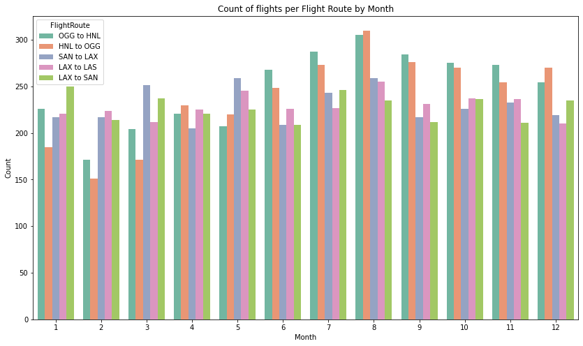

```python
plt.figure(figsize = (14,8))

sns.countplot(x="Month", data=most_flights, hue='FlightRoute', palette='Set2')

plt.xlabel('Month')
plt.ylabel('Count')
plt.title('Count of flights per Flight Route by Month')

plt.show()
```

Between September and December, these routes continue to have more flights than the others.

### Distribution by State

To make the most of the data, the States were queried to justify the number of people flying interstate and intrastate.

```python
df_q3['state'] = df_q3['Origin'].map(airport_df.set_index('iata')['state'])
df_q3
```

|  | Year | Month | DayofMonth | DayOfWeek | DepTime | CRSDepTime | ArrTime | CRSArrTime | UniqueCarrier | FlightNum | TailNum | ActualElapsedTime | CRSElapsedTime | AirTime | ArrDelay | DepDelay | Origin | Dest | Distance | TaxiIn | TaxiOut | Cancelled | CancellationCode | Diverted | CarrierDelay | WeatherDelay | NASDelay | SecurityDelay | LateAircraftDelay | … |
| --- | --- | --- | --- | --- | --- | --- | --- | --- | --- | --- | --- | --- | --- | --- | --- | --- | --- | --- | --- | --- | --- | --- | --- | --- | --- | --- | --- | --- | --- | --- |
| 11427221 | 2006 | 7 | 13 | 4 | 2132.0 | 2130 | 18.0 | 24 | AA | 314 | N072AA | 166.0 | 174.0 | 134.0 | -6.0 | 2.0 | MIA | JFK | 1090 | 11 | 21 | Not Cancelled | NaN | Not Diverted | 0 | 0 | 0 | 0 | 0 | … |
| 14306699 | 2006 | 12 | 9 | 6 | 2117.0 | 2120 | 2226.0 | 2225 | EV | 4520 | N758EV | 129.0 | 125.0 | 97.0 | 1.0 | -3.0 | SLC | SFO | 599 | 5 | 27 | Not Cancelled | NaN | Not Diverted | 0 | 0 | 0 | 0 | 0 | … |
| 13821464 | 2006 | 11 | 19 | 7 | 1247.0 | 1250 | 1415.0 | 1430 | NW | 1137 | N309US | 88.0 | 100.0 | 68.0 | -15.0 | -3.0 | BWI | DTW | 408 | 4 | 16 | Not Cancelled | NaN | Not Diverted | 0 | 0 | 0 | 0 | 0 | … |
| 1856981 | 2007 | 4 | 11 | 3 | 1720.0 | 1720 | 1813.0 | 1820 | WN | 39 | N503SW | 53.0 | 60.0 | 44.0 | -7.0 | 0.0 | HOU | HRL | 276 | 2 | 7 | Not Cancelled | NaN | Not Diverted | 0 | 0 | 0 | 0 | 0 | … |
| 14014779 | 2006 | 12 | 11 | 1 | 1832.0 | 1825 | 1937.0 | 1935 | WN | 2310 | N353 | 65.0 | 70.0 | 52.0 | 2.0 | 7.0 | BWI | PVD | 328 | 3 | 10 | Not Cancelled | NaN | Not Diverted | 0 | 0 | 0 | 0 | 0 | … |
| ... | ... | ... | ... | ... | ... | ... | ... | ... | ... | ... | ... | ... | ... | ... | ... | ... | ... | ... | ... | ... | ... | ... | ... | ... | ... | ... | ... | ... | ... | … |
| 481913 | 2007 | 1 | 24 | 3 | 955.0 | 1000 | 1208.0 | 1150 | 9E | 4759 | 88869E | 133.0 | 110.0 | 101.0 | 18.0 | -5.0 | RDU | IND | 489 | 9 | 23 | Not Cancelled | NaN | Not Diverted | 0 | 0 | 18 | 0 | 0 | … |
| 1630112 | 2007 | 3 | 6 | 2 | 1523.0 | 1530 | 1741.0 | 1735 | MQ | 4847 | N729AE | 138.0 | 125.0 | 96.0 | 6.0 | -7.0 | LGA | DTW | 501 | 13 | 29 | Not Cancelled | NaN | Not Diverted | 0 | 0 | 0 | 0 | 0 | … |
| 515861 | 2007 | 1 | 15 | 1 | 1548.0 | 1500 | 2037.0 | 1955 | AA | 1346 | N3CGAA | 169.0 | 175.0 | 136.0 | 42.0 | 48.0 | SNA | DFW | 1205 | 20 | 13 | Not Cancelled | NaN | Not Diverted | 0 | 0 | 4 | 0 | 38 | … |
| 5117427 | 2007 | 9 | 12 | 3 | 1414.0 | 1415 | 1727.0 | 1727 | XE | 7810 | N14173 | 133.0 | 132.0 | 109.0 | 0.0 | -1.0 | LAX | DEN | 862 | 5 | 19 | Not Cancelled | NaN | Not Diverted | 0 | 0 | 0 | 0 | 0 | … |
| 9527990 | 2006 | 4 | 13 | 4 | 1059.0 | 1106 | 1149.0 | 1200 | MQ | 3312 | N376AE | 50.0 | 54.0 | 28.0 | -11.0 | -7.0 | SPS | DFW | 113 | 12 | 10 | Not Cancelled | NaN | Not Diverted | 0 | 0 | 0 | 0 | 0 | … |

1431329 rows × 35 columns

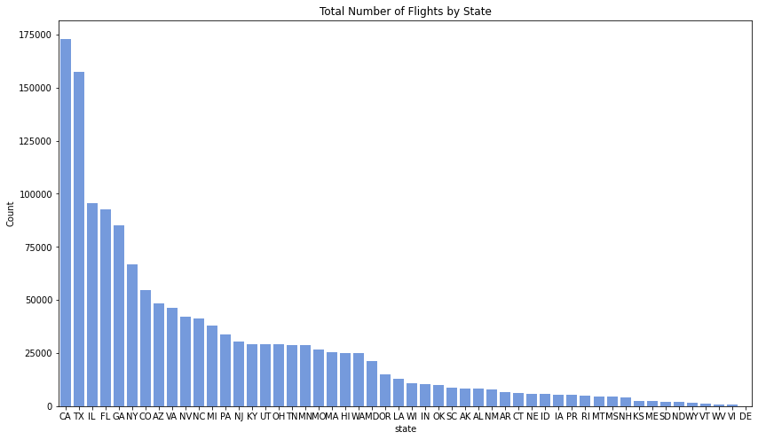

```python
plt.figure(figsize = (14,8))

order = df_q3['state'].value_counts().index
sns.countplot(data = df_q3 , x = 'state', order=order, color = 'cornflowerblue')

plt.xlabel('state')
plt.ylabel('Count')
plt.title('Total Number of Flights by State')

plt.show()
```

Top 3 popular states are:

1. California
2. Texas
3. Illinois

```python
pop_state = df_q3.query('(state == "CA") | (state == "TX") | (state == "IL")')
pop_state
```

|  | Year | Month | DayofMonth | DayOfWeek | DepTime | CRSDepTime | ArrTime | CRSArrTime | UniqueCarrier | FlightNum | TailNum | ActualElapsedTime | CRSElapsedTime | AirTime | ArrDelay | DepDelay | Origin | Dest | Distance | TaxiIn | TaxiOut | Cancelled | CancellationCode | Diverted | CarrierDelay | WeatherDelay | NASDelay | SecurityDelay | LateAircraftDelay | … |
| --- | --- | --- | --- | --- | --- | --- | --- | --- | --- | --- | --- | --- | --- | --- | --- | --- | --- | --- | --- | --- | --- | --- | --- | --- | --- | --- | --- | --- | --- | --- |
| 1856981 | 2007 | 4 | 11 | 3 | 1720.0 | 1720 | 1813.0 | 1820 | WN | 39 | N503SW | 53.0 | 60.0 | 44.0 | -7.0 | 0.0 | HOU | HRL | 276 | 2 | 7 | Not Cancelled | NaN | Not Diverted | 0 | 0 | 0 | 0 | 0 | … |
| 6351347 | 2007 | 11 | 12 | 1 | 1228.0 | 1220 | 1342.0 | 1337 | XE | 2981 | N12519 | 74.0 | 77.0 | 56.0 | 5.0 | 8.0 | BRO | IAH | 308 | 11 | 7 | Not Cancelled | NaN | Not Diverted | 0 | 0 | 0 | 0 | 0 | … |
| 7903147 | 2006 | 1 | 21 | 6 | 1345.0 | 1353 | 1750.0 | 1820 | AA | 736 | N440AA | 185.0 | 207.0 | 165.0 | -30.0 | -8.0 | DFW | LGA | 1389 | 4 | 16 | Not Cancelled | NaN | Not Diverted | 0 | 0 | 0 | 0 | 0 | … |
| 14487166 | 2006 | 12 | 6 | 3 | 638.0 | 640 | 756.0 | 800 | AA | 1907 | N4XDAA | 78.0 | 80.0 | 55.0 | -4.0 | -2.0 | SFO | LAX | 337 | 14 | 9 | Not Cancelled | NaN | Not Diverted | 0 | 0 | 0 | 0 | 0 | … |
| 8361093 | 2006 | 2 | 14 | 2 | 1755.0 | 1759 | 1859.0 | 1911 | MQ | 3511 | N617AE | 64.0 | 72.0 | 49.0 | -12.0 | -4.0 | DFW | AMA | 313 | 3 | 12 | Not Cancelled | NaN | Not Diverted | 0 | 0 | 0 | 0 | 0 | … |
| ... | ... | ... | ... | ... | ... | ... | ... | ... | ... | ... | ... | ... | ... | ... | ... | ... | ... | ... | ... | ... | ... | ... | ... | ... | ... | ... | ... | ... | ... | … |
| 7627462 | 2006 | 1 | 13 | 5 | 848.0 | 855 | 951.0 | 1000 | OO | 6022 | N229SW | 63.0 | 65.0 | 52.0 | -9.0 | -7.0 | SBA | SJC | 234 | 3 | 8 | Not Cancelled | NaN | Not Diverted | 0 | 0 | 0 | 0 | 0 | … |
| 5083828 | 2007 | 9 | 27 | 4 | 1201.0 | 1200 | 1255.0 | 1255 | WN | 24 | N502SW | 54.0 | 55.0 | 41.0 | 0.0 | 1.0 | HOU | DAL | 239 | 3 | 10 | Not Cancelled | NaN | Not Diverted | 0 | 0 | 0 | 0 | 0 | … |
| 515861 | 2007 | 1 | 15 | 1 | 1548.0 | 1500 | 2037.0 | 1955 | AA | 1346 | N3CGAA | 169.0 | 175.0 | 136.0 | 42.0 | 48.0 | SNA | DFW | 1205 | 20 | 13 | Not Cancelled | NaN | Not Diverted | 0 | 0 | 4 | 0 | 38 | … |
| 5117427 | 2007 | 9 | 12 | 3 | 1414.0 | 1415 | 1727.0 | 1727 | XE | 7810 | N14173 | 133.0 | 132.0 | 109.0 | 0.0 | -1.0 | LAX | DEN | 862 | 5 | 19 | Not Cancelled | NaN | Not Diverted | 0 | 0 | 0 | 0 | 0 | … |
| 9527990 | 2006 | 4 | 13 | 4 | 1059.0 | 1106 | 1149.0 | 1200 | MQ | 3312 | N376AE | 50.0 | 54.0 | 28.0 | -11.0 | -7.0 | SPS | DFW | 113 | 12 | 10 | Not Cancelled | NaN | Not Diverted | 0 | 0 | 0 | 0 | 0 | … |

425970 rows × 35 columns

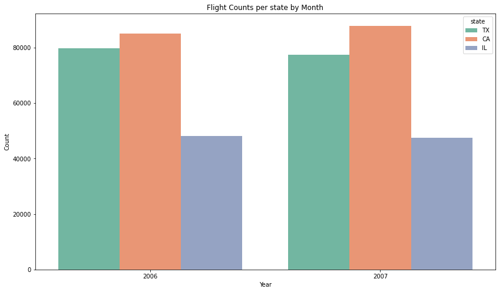

```python
plt.figure(figsize = (14,8))

sns.countplot(x="Year", data=pop_state, hue='state', palette = 'Set2')

plt.xlabel('Year')
plt.ylabel('Count')
plt.title('Flight Counts per state by Month')

plt.show()
```

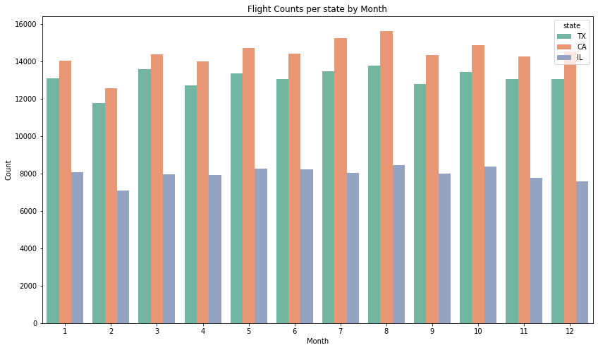

```python
plt.figure(figsize = (14,8))

sns.countplot(x="Month", data=pop_state, hue='state', palette = 'Set2')

plt.xlabel('Month')
plt.ylabel('Count')
plt.title('Flight Counts per state by Month')

plt.show()
```

# Q4. Can cascading failures where an airport's delay causing delay in another be detected?

Cascading failures occur when a flight delay for one plane in an airport causes a flight delay in another.

This is explained by the existing variable 'LateAircraftDelay' which describes how a particular flight delayed in its Origin arrives late in its Destination, then affecting the next flight's departure since the same plane was used. The ripple impact of a previous delay at downstream airports hence causes cascading failures.

Since Tail Numbers are identification numbers on aircraft, it will be easier to focus on data with ‘LateAircraftDelay’, then focus on a selected aircraft and observe its flight schedule.

We will approach the question as follow:

- Methodology
- Initial Test
- Secondary Testing

```python
merged_df['TailNum'].value_counts()
```

```
0         177944
000000     21644
N308SW      8569
N478HA      8195
N479HA      8079
           ...
N194JB         1
N78009         1
N857NW         1
N576SK         1
N824\A         1
Name: TailNum, Length: 5817, dtype: int64
```

'0' and '000000' are likely private confidential TailNums, so we ignore those data and focus on the top 2 highest counts of TailNum:

- N308SW
- N478HA

## Methodology

We will approach the dataset in the following way to effectively illustrate cascading failures, that is, delays in one airport will cause delays in another:

1. Find Highest ‘TailNum’ count (Higher chance of continuous flights in a day)
2. Extract data fitting condition of Highest ‘TailNum’ & 'LateAircraftDelay' > 15 minutes
3. Find Highest ‘Date’ count from extracted data (Higher chance of continuous flights in a day)
4. Extract overall data fitting conditions of Highest ‘TailNum’ & Highest ‘Date’ count
5. Sort data by ‘DepTime’ (To see the flight schedule of same aircraft by Departure Timing)

This approach will allow us to assess if a delayed flight in one airport may cause a delay in another.  
To ensure that the data extraction and analysis approaches are valid, two separate tests will be conducted.

## Initial Test

The initial test used N308SW to identify the highest date counts.

```python
# First extraction of data with top most TailNum counts
df_q4_1 = merged_df.query("TailNum == 'N308SW' & LateAircraftDelay > 15 ")
```

```python
df_q4_1['Date'].value_counts().head()
```

```
2006-01-02    9
2006-04-21    9
2007-01-31    9
2006-06-25    8
2006-05-21    8
Name: Date, dtype: int64
```

We will focus on the date with the highest count to see if there is any relation that leads to cascading failure.

```python
# Extracting dataset that matches our findings
df_q4_1 = merged_df.query("Date == '2006-01-02' & TailNum == 'N308SW'")
df_q4_1.sort_values(by=['DepTime'])
```

|  | Year | Month | DayofMonth | DayOfWeek | DepTime | CRSDepTime | ArrTime | CRSArrTime | UniqueCarrier | FlightNum | TailNum | ActualElapsedTime | CRSElapsedTime | AirTime | ArrDelay | DepDelay | Origin | Dest | Distance | TaxiIn | TaxiOut | Cancelled | CancellationCode | Diverted | CarrierDelay | WeatherDelay | NASDelay | SecurityDelay | LateAircraftDelay | … |
| --- | --- | --- | --- | --- | --- | --- | --- | --- | --- | --- | --- | --- | --- | --- | --- | --- | --- | --- | --- | --- | --- | --- | --- | --- | --- | --- | --- | --- | --- | --- |
| 7486653 | 2006 | 1 | 2 | 1 | 630.0 | 630 | 743.0 | 730 | WN | 1783 | N308SW | 73.0 | 60.0 | 55.0 | 13.0 | 0.0 | LAS | LAX | 236 | 4 | 14 | Not Cancelled | NaN | Not Diverted | 0 | 0 | 0 | 0 | 0 | … |
| 7486870 | 2006 | 1 | 2 | 1 | 809.0 | 800 | 929.0 | 915 | WN | 2662 | N308SW | 80.0 | 75.0 | 65.0 | 14.0 | 9.0 | LAX | OAK | 337 | 3 | 12 | Not Cancelled | NaN | Not Diverted | 0 | 0 | 0 | 0 | 0 | … |
| 7611530 | 2006 | 1 | 2 | 1 | 955.0 | 947 | 1057.0 | 1052 | OO | 3717 | N308SW | 62.0 | 65.0 | 40.0 | 5.0 | 8.0 | SLC | TWF | 175 | 3 | 19 | Not Cancelled | NaN | Not Diverted | 0 | 0 | 0 | 0 | 0 | … |
| 7487432 | 2006 | 1 | 2 | 1 | 1012.0 | 950 | 1139.0 | 1105 | WN | 1717 | N308SW | 87.0 | 75.0 | 76.0 | 34.0 | 22.0 | OAK | ONT | 361 | 3 | 8 | Not Cancelled | NaN | Not Diverted | 8 | 0 | 12 | 0 | 14 | … |
| 7611531 | 2006 | 1 | 2 | 1 | 1147.0 | 1130 | 1242.0 | 1231 | OO | 3718 | N308SW | 55.0 | 61.0 | 38.0 | 11.0 | 17.0 | TWF | SLC | 175 | 10 | 7 | Not Cancelled | NaN | Not Diverted | 0 | 0 | 0 | 0 | 0 | … |
| 7487573 | 2006 | 1 | 2 | 1 | 1203.0 | 1130 | 1321.0 | 1250 | WN | 1067 | N308SW | 78.0 | 80.0 | 63.0 | 31.0 | 33.0 | ONT | SMF | 389 | 5 | 10 | Not Cancelled | NaN | Not Diverted | 0 | 0 | 0 | 0 | 31 | … |
| 7611487 | 2006 | 1 | 2 | 1 | 1302.0 | 1105 | 1408.0 | 1204 | OO | 3680 | N308SW | 66.0 | 59.0 | 42.0 | 124.0 | 117.0 | SLC | PIH | 150 | 5 | 19 | Not Cancelled | NaN | Not Diverted | 0 | 0 | 0 | 0 | 124 | … |
| 7611488 | 2006 | 1 | 2 | 1 | 1418.0 | 1335 | 1509.0 | 1424 | OO | 3680 | N308SW | 51.0 | 49.0 | 37.0 | 45.0 | 43.0 | PIH | SLC | 150 | 6 | 8 | Not Cancelled | NaN | Not Diverted | 0 | 0 | 0 | 0 | 45 | … |
| 7488368 | 2006 | 1 | 2 | 1 | 1420.0 | 1315 | 1535.0 | 1430 | WN | 1417 | N308SW | 75.0 | 75.0 | 65.0 | 65.0 | 65.0 | SMF | ONT | 389 | 5 | 5 | Not Cancelled | NaN | Not Diverted | 34 | 0 | 0 | 0 | 31 | … |
| 7487566 | 2006 | 1 | 2 | 1 | 1610.0 | 1455 | 1719.0 | 1610 | WN | 936 | N308SW | 69.0 | 75.0 | 60.0 | 69.0 | 75.0 | ONT | SJC | 333 | 4 | 5 | Not Cancelled | NaN | Not Diverted | 9 | 0 | 0 | 0 | 60 | … |
| 7611505 | 2006 | 1 | 2 | 1 | 1627.0 | 1540 | 1635.0 | 1541 | OO | 3699 | N308SW | 68.0 | 61.0 | 51.0 | 54.0 | 47.0 | SLC | EKO | 200 | 4 | 13 | Not Cancelled | NaN | Not Diverted | 0 | 54 | 0 | 0 | 0 | … |
| 7611506 | 2006 | 1 | 2 | 1 | 1648.0 | 1600 | 1844.0 | 1757 | OO | 3699 | N308SW | 56.0 | 57.0 | 45.0 | 47.0 | 48.0 | EKO | SLC | 200 | 4 | 7 | Not Cancelled | NaN | Not Diverted | 0 | 47 | 0 | 0 | 0 | … |
| 7488258 | 2006 | 1 | 2 | 1 | 1750.0 | 1635 | 1927.0 | 1820 | WN | 936 | N308SW | 97.0 | 105.0 | 83.0 | 67.0 | 75.0 | SJC | PDX | 569 | 5 | 9 | Not Cancelled | NaN | Not Diverted | 5 | 0 | 0 | 0 | 62 | … |
| 7487633 | 2006 | 1 | 2 | 1 | 2000.0 | 1845 | 2135.0 | 2030 | WN | 1091 | N308SW | 95.0 | 105.0 | 87.0 | 65.0 | 75.0 | PDX | SJC | 569 | 3 | 5 | Not Cancelled | NaN | Not Diverted | 7 | 0 | 0 | 0 | 58 | … |
| 7611544 | 2006 | 1 | 2 | 1 | 2110.0 | 2055 | 2233.0 | 2221 | OO | 3729 | N308SW | 83.0 | 86.0 | 57.0 | 12.0 | 15.0 | SLC | COD | 298 | 6 | 20 | Not Cancelled | NaN | Not Diverted | 0 | 0 | 0 | 0 | 0 | … |
| 7488239 | 2006 | 1 | 2 | 1 | 2155.0 | 2050 | 2305.0 | 2200 | WN | 1091 | N308SW | 70.0 | 70.0 | 52.0 | 65.0 | 65.0 | SJC | LAX | 308 | 7 | 11 | Not Cancelled | NaN | Not Diverted | 0 | 0 | 0 | 0 | 65 | … |
| 7486831 | 2006 | 1 | 2 | 1 | 2322.0 | 2225 | 20.0 | 2325 | WN | 1091 | N308SW | 58.0 | 60.0 | 48.0 | 55.0 | 57.0 | LAX | LAS | 236 | 4 | 6 | Not Cancelled | NaN | Not Diverted | 0 | 0 | 0 | 0 | 55 | … |

```python
# Important Columns
df_q4_1.query("UniqueCarrier == 'WN'")[['FlightNum','DepTime', 'CRSDepTime','ArrTime','CRSArrTime','TailNum','ArrDelay','DepDelay','Origin','Dest','LateAircraftDelay','Date']].sort_values(by=['DepTime'])
```

|  | FlightNum | DepTime | CRSDepTime | ArrTime | CRSArrTime | TailNum | ArrDelay | DepDelay | Origin | Dest | LateAircraftDelay | Date |
| --- | --- | --- | --- | --- | --- | --- | --- | --- | --- | --- | --- | --- |
| 7486653 | 1783 | 630.0 | 630 | 743.0 | 730 | N308SW | 13.0 | 0.0 | LAS | LAX | 0 | 2006-01-02 |
| 7486870 | 2662 | 809.0 | 800 | 929.0 | 915 | N308SW | 14.0 | 9.0 | LAX | OAK | 0 | 2006-01-02 |
| 7487432 | 1717 | 1012.0 | 950 | 1139.0 | 1105 | N308SW | 34.0 | 22.0 | OAK | ONT | 14 | 2006-01-02 |
| 7487573 | 1067 | 1203.0 | 1130 | 1321.0 | 1250 | N308SW | 31.0 | 33.0 | ONT | SMF | 31 | 2006-01-02 |
| 7488368 | 1417 | 1420.0 | 1315 | 1535.0 | 1430 | N308SW | 65.0 | 65.0 | SMF | ONT | 31 | 2006-01-02 |
| 7487566 | 936 | 1610.0 | 1455 | 1719.0 | 1610 | N308SW | 69.0 | 75.0 | ONT | SJC | 60 | 2006-01-02 |
| 7488258 | 936 | 1750.0 | 1635 | 1927.0 | 1820 | N308SW | 67.0 | 75.0 | SJC | PDX | 62 | 2006-01-02 |
| 7487633 | 1091 | 2000.0 | 1845 | 2135.0 | 2030 | N308SW | 65.0 | 75.0 | PDX | SJC | 58 | 2006-01-02 |
| 7488239 | 1091 | 2155.0 | 2050 | 2305.0 | 2200 | N308SW | 65.0 | 65.0 | SJC | LAX | 65 | 2006-01-02 |
| 7486831 | 1091 | 2322.0 | 2225 | 20.0 | 2325 | N308SW | 55.0 | 57.0 | LAX | LAS | 55 | 2006-01-02 |

It is clear that one flight's delay in an airport can cause cascading failures in another.  
We can observe from FlightNum 2662 that there was a 14 minutes ArrDelay in the Destination Airport (OAK). This led to the following FlightNum 1717 that was supposed to also depart from OAK to ONT to be delayed for 22 minutes (14 being LateAircraftDelay).

Then the delay for this flight also caused the next FlightNum 1067 from ONT to SMF to be delayed for 33 minutes. The delay persisted till the end of day near midnight.

Taking Flight 1417 as an example: has to depart at 1315 (1:15pm) but delayed for 65 mins till 1420 (2:20pm), flying from SMF to ONT. Supposed to reach 1430 (2:30pm) but reached 1535 (3:25pm).

This one-hour delay thereafter caused the next flight from ONT to SJC (FlightNum 936) to be delayed for 75 minutes (60 mins for LateAircraftDelay) also since its scheduled departure time is at 1455 (2:55pm), but it only took off at 1610 (4:10pm). It also arrived 69 minutes later than expected time of 1610 at 1719.

Since the CRSDepTime overlapped with its previous flight’s ArrTime, the delay persisted and escalated till near midnight of the day, resulting in cascading failures.

## Secondary Testing

The secondary test used N478HA to identify the highest date counts.

```python
# First extraction of data with second most TailNum counts
df_q4_2 = merged_df.query("TailNum == 'N478HA' & LateAircraftDelay > 15 ")
```

```python
df_q4_2['Date'].value_counts().head()
```

```
2006-03-31    8
2007-09-08    7
2007-09-28    7
2006-04-28    6
2006-12-17    5
Name: Date, dtype: int64
```

We will focus on the date with the highest count to see if there is any relation that leads to cascading failure.

```python
# Extracting dataset that matches our findings
df_q4_2 = merged_df.query("Date == '2006-03-31' & TailNum == 'N478HA'")
df_q4_2.sort_values(by=['DepTime'])
```

|  | Year | Month | DayofMonth | DayOfWeek | DepTime | CRSDepTime | ArrTime | CRSArrTime | UniqueCarrier | FlightNum | TailNum | ActualElapsedTime | CRSElapsedTime | AirTime | ArrDelay | DepDelay | Origin | Dest | Distance | TaxiIn | TaxiOut | Cancelled | CancellationCode | Diverted | CarrierDelay | WeatherDelay | NASDelay | SecurityDelay | LateAircraftDelay | … |
| --- | --- | --- | --- | --- | --- | --- | --- | --- | --- | --- | --- | --- | --- | --- | --- | --- | --- | --- | --- | --- | --- | --- | --- | --- | --- | --- | --- | --- | --- | --- |
| 8922601 | 2006 | 3 | 31 | 5 | 518.0 | 520 | 559.0 | 557 | HA | 106 | N478HA | 41.0 | 37.0 | 24.0 | 2.0 | -2.0 | HNL | OGG | 100 | 5 | 12 | Not Cancelled | NaN | Not Diverted | 0 | 0 | 0 | 0 | 0 | … |
| 8922574 | 2006 | 3 | 31 | 5 | 623.0 | 625 | 701.0 | 659 | HA | 105 | N478HA | 38.0 | 34.0 | 24.0 | 2.0 | -2.0 | OGG | HNL | 100 | 8 | 6 | Not Cancelled | NaN | Not Diverted | 0 | 0 | 0 | 0 | 0 | … |
| 8922934 | 2006 | 3 | 31 | 5 | 728.0 | 735 | 819.0 | 818 | HA | 118 | N478HA | 51.0 | 43.0 | 30.0 | 1.0 | -7.0 | HNL | KOA | 163 | 4 | 17 | Not Cancelled | NaN | Not Diverted | 0 | 0 | 0 | 0 | 0 | … |
| 8922903 | 2006 | 3 | 31 | 5 | 844.0 | 848 | 936.0 | 928 | HA | 117 | N478HA | 52.0 | 40.0 | 41.0 | 8.0 | -4.0 | KOA | HNL | 163 | 4 | 7 | Not Cancelled | NaN | Not Diverted | 0 | 0 | 0 | 0 | 0 | … |
| 8924619 | 2006 | 3 | 31 | 5 | 1002.0 | 1005 | 1037.0 | 1042 | HA | 316 | N478HA | 35.0 | 37.0 | 22.0 | -5.0 | -3.0 | HNL | OGG | 100 | 5 | 8 | Not Cancelled | NaN | Not Diverted | 0 | 0 | 0 | 0 | 0 | … |
| 8924588 | 2006 | 3 | 31 | 5 | 1130.0 | 1110 | 1222.0 | 1144 | HA | 315 | N478HA | 52.0 | 34.0 | 35.0 | 38.0 | 20.0 | OGG | HNL | 100 | 10 | 7 | Not Cancelled | NaN | Not Diverted | 0 | 20 | 0 | 0 | 18 | … |
| 8923833 | 2006 | 3 | 31 | 5 | 1326.0 | 1215 | 1418.0 | 1258 | HA | 178 | N478HA | 52.0 | 43.0 | 31.0 | 80.0 | 71.0 | HNL | KOA | 163 | 7 | 14 | Not Cancelled | NaN | Not Diverted | 0 | 33 | 0 | 0 | 47 | … |
| 8923864 | 2006 | 3 | 31 | 5 | 1450.0 | 1328 | 1524.0 | 1357 | HA | 179 | N478HA | 34.0 | 29.0 | 18.0 | 87.0 | 82.0 | KOA | OGG | 84 | 6 | 10 | Not Cancelled | NaN | Not Diverted | 2 | 0 | 0 | 0 | 85 | … |
| 8923895 | 2006 | 3 | 31 | 5 | 1544.0 | 1425 | 1628.0 | 1459 | HA | 179 | N478HA | 44.0 | 34.0 | 27.0 | 89.0 | 79.0 | OGG | HNL | 100 | 8 | 9 | Not Cancelled | NaN | Not Diverted | 0 | 0 | 0 | 0 | 89 | … |
| 8924412 | 2006 | 3 | 31 | 5 | 1702.0 | 1545 | 1800.0 | 1636 | HA | 262 | N478HA | 58.0 | 51.0 | 36.0 | 84.0 | 77.0 | HNL | ITO | 216 | 6 | 16 | Not Cancelled | NaN | Not Diverted | 0 | 0 | 0 | 0 | 84 | … |
| 8924381 | 2006 | 3 | 31 | 5 | 1824.0 | 1705 | 1914.0 | 1752 | HA | 261 | N478HA | 50.0 | 47.0 | 37.0 | 82.0 | 79.0 | ITO | HNL | 216 | 6 | 7 | Not Cancelled | NaN | Not Diverted | 0 | 0 | 0 | 0 | 82 | … |
| 8924557 | 2006 | 3 | 31 | 5 | 1944.0 | 1825 | 2026.0 | 1908 | HA | 308 | N478HA | 42.0 | 43.0 | 29.0 | 78.0 | 79.0 | HNL | KOA | 163 | 4 | 9 | Not Cancelled | NaN | Not Diverted | 0 | 0 | 0 | 0 | 78 | … |
| 8924526 | 2006 | 3 | 31 | 5 | 2047.0 | 1938 | 2130.0 | 2018 | HA | 307 | N478HA | 43.0 | 40.0 | 30.0 | 72.0 | 69.0 | KOA | HNL | 163 | 6 | 7 | Not Cancelled | NaN | Not Diverted | 0 | 0 | 0 | 0 | 72 | … |

```python
df_q4_2[['FlightNum','DepTime', 'CRSDepTime','ArrTime','CRSArrTime','TailNum','ArrDelay','DepDelay','Origin','Dest','LateAircraftDelay','Date']].sort_values(by=['DepTime'])[-8:]
```

|  | FlightNum | DepTime | CRSDepTime | ArrTime | CRSArrTime | TailNum | ArrDelay | DepDelay | Origin | Dest | LateAircraftDelay | Date |
| --- | --- | --- | --- | --- | --- | --- | --- | --- | --- | --- | --- | --- |
| 8924588 | 315 | 1130.0 | 1110 | 1222.0 | 1144 | N478HA | 38.0 | 20.0 | OGG | HNL | 18 | 2006-03-31 |
| 8923833 | 178 | 1326.0 | 1215 | 1418.0 | 1258 | N478HA | 80.0 | 71.0 | HNL | KOA | 47 | 2006-03-31 |
| 8923864 | 179 | 1450.0 | 1328 | 1524.0 | 1357 | N478HA | 87.0 | 82.0 | KOA | OGG | 85 | 2006-03-31 |
| 8923895 | 179 | 1544.0 | 1425 | 1628.0 | 1459 | N478HA | 89.0 | 79.0 | OGG | HNL | 89 | 2006-03-31 |
| 8924412 | 262 | 1702.0 | 1545 | 1800.0 | 1636 | N478HA | 84.0 | 77.0 | HNL | ITO | 84 | 2006-03-31 |
| 8924381 | 261 | 1824.0 | 1705 | 1914.0 | 1752 | N478HA | 82.0 | 79.0 | ITO | HNL | 82 | 2006-03-31 |
| 8924557 | 308 | 1944.0 | 1825 | 2026.0 | 1908 | N478HA | 78.0 | 79.0 | HNL | KOA | 78 | 2006-03-31 |
| 8924526 | 307 | 2047.0 | 1938 | 2130.0 | 2018 | N478HA | 72.0 | 69.0 | KOA | HNL | 72 | 2006-03-31 |

Taking FlightNum 178 as an example: has to depart at 1215 (12:pm) but delayed for 71 mins till 1326 (1:26pm), flying from HNL to KOA.

Supposed to reach 1258 (12:58pm) but reached 80 minutes later 1418 (2:18pm).

This 80 mins delay thereafter caused the next flight from KOA to OGG (FlightNum179) to be delayed for 82 minutes also since its scheduled departure time is at 1328 (1:28pm), but it only took off at 1450 (2:50pm). It also arrived 87 minutes later than expected time of 1357 at 1524.

Hence, a 38-min ArrDelay from FlightNum 315 triggered a snowball effect, causing all subsequent flights until FlightNum 307 to have ArrDelay ranging from 38 minutes to 89 minutes, with the majority attributable to LateAircraftDelay.

It is also worth noting the instances where subsequent flights might not use the same TailNum, but they are assumed due to a lack of schedule information. A total of two tests were conducted in Python, to demonstrate the same effect of cascading failures where delays at one airport causes delays in another. The previous flight's late arrival, which used the same plane that would be departing, caused the subsequent flight’s delay. As a result, the current flight will depart late, setting off a chain reaction causing passengers at other airports to board the plane much later as well.

# Q5. Construct a model predicting delays.

With the flight data labelled, Supervised Learning algorithms such as Multiple Linear Regression and Random Forest are used to construct Regression and Classification prediction models in Python.

This works by allowing the model to predict the label of new data points based on past data.

To predict delays, these few supervised learning models with selected variables are used:

- Multiple Linear Regression
- Random Forest
- Logistic Regression

```python
from sklearn.model_selection import train_test_split, cross_val_score, cross_val_predict
from sklearn.tree import DecisionTreeClassifier
from sklearn.ensemble import BaggingClassifier, RandomForestClassifier
from sklearn import metrics
from sklearn.metrics import mean_squared_error
```

```python
# Create new dataframe
df_q5 = flight_notcancelled.copy()
df_q5.head(5)
```

|  | Year | Month | DayofMonth | DayOfWeek | DepTime | CRSDepTime | ArrTime | CRSArrTime | UniqueCarrier | FlightNum | TailNum | ActualElapsedTime | CRSElapsedTime | AirTime | ArrDelay | DepDelay | Origin | Dest | Distance | TaxiIn | TaxiOut | Cancelled | CancellationCode | Diverted | CarrierDelay | WeatherDelay | NASDelay | SecurityDelay | LateAircraftDelay | … |
| --- | --- | --- | --- | --- | --- | --- | --- | --- | --- | --- | --- | --- | --- | --- | --- | --- | --- | --- | --- | --- | --- | --- | --- | --- | --- | --- | --- | --- | --- | --- |
| 11427221 | 2006 | 7 | 13 | 4 | 2132.0 | 2130 | 18.0 | 24 | AA | 314 | N072AA | 166.0 | 174.0 | 134.0 | -6.0 | 2.0 | MIA | JFK | 1090 | 11 | 21 | Not Cancelled | NaN | Not Diverted | 0 | 0 | 0 | 0 | 0 | … |
| 14306699 | 2006 | 12 | 9 | 6 | 2117.0 | 2120 | 2226.0 | 2225 | EV | 4520 | N758EV | 129.0 | 125.0 | 97.0 | 1.0 | -3.0 | SLC | SFO | 599 | 5 | 27 | Not Cancelled | NaN | Not Diverted | 0 | 0 | 0 | 0 | 0 | … |
| 13821464 | 2006 | 11 | 19 | 7 | 1247.0 | 1250 | 1415.0 | 1430 | NW | 1137 | N309US | 88.0 | 100.0 | 68.0 | -15.0 | -3.0 | BWI | DTW | 408 | 4 | 16 | Not Cancelled | NaN | Not Diverted | 0 | 0 | 0 | 0 | 0 | … |
| 1856981 | 2007 | 4 | 11 | 3 | 1720.0 | 1720 | 1813.0 | 1820 | WN | 39 | N503SW | 53.0 | 60.0 | 44.0 | -7.0 | 0.0 | HOU | HRL | 276 | 2 | 7 | Not Cancelled | NaN | Not Diverted | 0 | 0 | 0 | 0 | 0 | … |
| 14014779 | 2006 | 12 | 11 | 1 | 1832.0 | 1825 | 1937.0 | 1935 | WN | 2310 | N353 | 65.0 | 70.0 | 52.0 | 2.0 | 7.0 | BWI | PVD | 328 | 3 | 10 | Not Cancelled | NaN | Not Diverted | 0 | 0 | 0 | 0 | 0 | … |

```python
# Create features (X) and labels (Y)
X = df_q5[['DepDelay','Distance','TaxiIn','TaxiOut','ActualElapsedTime','AirTime','CarrierDelay','WeatherDelay','NASDelay','SecurityDelay','LateAircraftDelay']]
Y = df_q5['ArrDelay']
```

```python
# Split into train-test data
X_test, X_train, Y_test, Y_train = train_test_split(X, Y, test_size=0.30, random_state=42)
print(X_train.shape, X_train.shape)
print(Y_test.shape, Y_test.shape)
```

```
(429399, 11) (429399, 11)
(1001930,) (1001930,)
```

### Multiple Linear Regression

MLR is a regression model which enables us to understand and estimate relationships between multiple variables.

```python
# Load model
from sklearn.linear_model import LinearRegression
lm = LinearRegression()
lm.fit(X_train, Y_train)
```

```
LinearRegression()
```

```python
# Predicting delays
mlr_pred  = lm.predict(X_test)
mlr_pred
```

```
array([ 4.92213735, 68.93785102, 29.24754481, ..., -3.67150069,
       16.04323536, -8.29463399])
```

With Y: ArrDelay, the Linear Regression model is loaded first, then fitted to the training data.  
Next, the model is tested against unseen X_test data to get predictions.

```python
# Evaluating Model & Accuracy Score
print('The R2 score is' , lm.score(X_test,Y_test))
print('The Mean Square Error (MSE) is',mean_squared_error(Y_test,mlr_pred))
print('The Root Mean Square Error (RMSE) is', np.sqrt(mean_squared_error(Y_test,mlr_pred)))
```

```
The R2 score is 0.9571000082975876
The Mean Square Error (MSE) is 62.13641092589014
The Root Mean Square Error (RMSE) is 7.882665217164188
```

The R2 score is 0.957, where predictor variables in the model explained 95.7% of the variation in Y.  
Root Mean Square Error (RMSE) representing the standard deviation of prediction errors is considerably fitting with 7.88.

```python
# Use model to predict on feature X
mlr_wpred = lm.predict(X)
mlr_wpred
```

```
array([-2.61439299,  1.02934672, -3.90919782, ..., 38.45652781,
       -4.86880419, -6.55794758])
```

Then, the model is predicted on the feature X to get the full prediction set.

```python
# Creating copy of data for regression
reg_df_q5 = df_q5
```

```python
# Create new column of MLR prediction
reg_df_q5['MLR_DelayPrediction'] = mlr_wpred
```

```python
# Getting output results
mlr_results = reg_df_q5.loc[(reg_df_q5['MLR_DelayPrediction'] == mlr_wpred)]
mlr_results[['UniqueCarrier','Origin','Dest','ArrDelay','MLR_DelayPrediction','DelayStatus']][0:5]
```

|  | UniqueCarrier | Origin | Dest | ArrDelay | MLR_DelayPrediction | DelayStatus |
| --- | --- | --- | --- | --- | --- | --- |
| 11427221 | AA | MIA | JFK | -6.0 | -2.614393 | 0 |
| 14306699 | EV | SLC | SFO | 1.0 | 1.029347 | 0 |
| 13821464 | NW | BWI | DTW | -15.0 | -3.909198 | 0 |
| 1856981 | WN | HOU | HRL | -7.0 | -7.567691 | 0 |
| 14014779 | WN | BWI | PVD | 2.0 | -3.301670 | 0 |

### Random Forest

Used for Classification and Regression, Random Forest is a Supervised Learning algorithm that constructs many decision trees.  
For this, the Regression method will be used, with Y being continuous (ArrDelay), giving an output of the mean prediction of decision trees.

```python
# Load model
from sklearn.ensemble import RandomForestRegressor
rf_reg = RandomForestRegressor(n_estimators=10, random_state=42)
rf_reg.fit(X_train,Y_train)
```

```
RandomForestRegressor(n_estimators=10, random_state=42)
```

```python
# Predicting delays
rf_regpred = rf_reg.predict(X_test)
rf_regpred
```

```
array([ 0.3, 74.9, 30. , ..., -3.7, 15. , -8.9])
```

The Random Forest Regression model is first loaded then fitted to the Trainset. Next, the model is tested against unseen X_test data for predictions.

```python
# Evaluating Model & Accuracy Score
print('The R2 score is' , rf_reg.score(X_test,Y_test))
print('The Mean Square Error (MSE) is',mean_squared_error(Y_test,rf_regpred))
print('The Root Mean Square Error (RMSE) is', np.sqrt(mean_squared_error(Y_test,rf_regpred)))
```

```
The R2 score is 0.9624242454978393
The Mean Square Error (MSE) is 54.42477795316974
The Root Mean Square Error (RMSE) is 7.377315091086305
```

The R2 score is 0.962, where predictor variables in the model explains 96.2% of the variation in Y.  
RMSE is considerably fitting with 7.38.

```python
# Use model to predict on whole dataset
rf_pred = rf_reg.predict(X)
rf_pred
```

```
array([ -0.3,   3.6, -11.8, ...,  43. ,  -5.9,  -5.8])
```

Then, the model is predicted on the feature X to get the full prediction set, resulting in the above predicted output.

```python
# Create new column of RF prediction
reg_df_q5['RF_DelayPrediction'] = rf_pred
```

```python
rf_results = reg_df_q5.loc[(reg_df_q5['RF_DelayPrediction'] == rf_pred)]
rf_results[['UniqueCarrier','Origin','Dest','ArrDelay','RF_DelayPrediction','DelayStatus']][:5]
```

|  | UniqueCarrier | Origin | Dest | ArrDelay | RF_DelayPrediction | DelayStatus |
| --- | --- | --- | --- | --- | --- | --- |
| 11427221 | AA | MIA | JFK | -6.0 | -0.300 | 0 |
| 14306699 | EV | SLC | SFO | 1.0 | 3.600 | 0 |
| 13821464 | NW | BWI | DTW | -15.0 | -11.800 | 0 |
| 1856981 | WN | HOU | HRL | -7.0 | -5.975 | 0 |
| 14014779 | WN | BWI | PVD | 2.0 | 0.700 | 0 |

### Logistic Regression

Logistic Regression is a Classification model that predicts a binary outcome (DelayStatus).

```python
# Create features (X) and labels (Y)
X1 = df_q5[['DepDelay','Distance','TaxiIn','TaxiOut','ActualElapsedTime','AirTime','CarrierDelay','WeatherDelay','NASDelay','SecurityDelay','LateAircraftDelay']]
Y2 = df_q5['DelayStatus']
```

```python
x_train_d, x_test_d, y_train_d, y_test_d = train_test_split(X1, Y2, test_size = 0.3, random_state=42)
```

```python
from sklearn.linear_model import LogisticRegression
LR_model = LogisticRegression()
```

```python
LR_model.fit(x_train_d, y_train_d)
LR_regpred = LR_model.predict(x_test_d)
```

```python
# Use model to predict on whole dataset
LR_pred = LR_model.predict(X1)
LR_pred
```

```
array(['0', '0', '0', ..., '1', '0', '0'], dtype=object)
```

```python
# Create new column of LR prediction
reg_df_q5['LR_Prediction'] = LR_pred
```

```python
# Selected dataframes and prediction output
LR_results = reg_df_q5.loc[(reg_df_q5['LR_Prediction'] == LR_pred)]
LR_results[['UniqueCarrier','Origin','Dest','LR_Prediction','DelayStatus']][0:5]
```

|  | UniqueCarrier | Origin | Dest | LR_Prediction | DelayStatus |
| --- | --- | --- | --- | --- | --- |
| 11427221 | AA | MIA | JFK | 0 | 0 |
| 14306699 | EV | SLC | SFO | 0 | 0 |
| 13821464 | NW | BWI | DTW | 0 | 0 |
| 1856981 | WN | HOU | HRL | 0 | 0 |
| 14014779 | WN | BWI | PVD | 0 | 0 |

```python
# Classification report
from sklearn.metrics import classification_report
print(classification_report(y_test_d, LR_regpred))
```

```
              precision    recall  f1-score   support

           0       0.99      0.99      0.99    330709
           1       0.96      0.98      0.97     98690

    accuracy                           0.99    429399
   macro avg       0.98      0.98      0.98    429399
weighted avg       0.99      0.99      0.99    429399
```

```python
# Confusion Matrix
from sklearn.metrics import confusion_matrix
print(confusion_matrix(y_test_d, LR_regpred))
```

```
[[327185   3524]
 [  2065  96625]]
```

```python
# Evaluating Model & Accuracy Score
print('The R2 score is' , LR_model.score(x_test_d,y_test_d))
print('The Mean Square Error (MSE) is',mean_squared_error(y_test_d,LR_regpred))
print('The Root Mean Square Error (RMSE) is', np.sqrt(mean_squared_error(y_test_d,LR_regpred)))
```

```
The R2 score is 0.9869841336379451
The Mean Square Error (MSE) is 0.013015866362054871
The Root Mean Square Error (RMSE) is 0.11408709989326081
```

With an R2 value of 0.98, predictor variables can explain 98% of the variation in Y (DelayStatus).

In total, two regression and one classification methods were tested out in Python. Overall, the best model to predict the continuous ArrDelay would be Random Forest with 96.2% accuracy, followed by MLR with 95.7% accuracy. To predict the binary outcome DelayStatus, Logistic Regression model is around 98% accurate.